# Script_Proyecto_Final

Sebastian Carrero - Robert Garcia

2023-05-20

### Llamamos librerias

```r
library(tidyverse)
```

```r
library(dplyr)
library(ggplot2)
library(corrplot)
library(broom)
library(readr)
library(ggfortify)
```

### Se descargan todas las tablas de con la data: Área - Características generales (Personas).csv para todos los meses del año 2021

```r
setwd("C:/SEBASTIAN/ESP. ANALITICA DE DATOS/ETL/Proyecto_Final_Extraccion")
getwd()
```

```
## [1] "C:/SEBASTIAN/ESP. ANALITICA DE DATOS/ETL/Proyecto_Final_Extraccion"
```

```r
list.files()
```

```
## [1] "Proyecto_Final_Extraccion.Rproj" "Tallar_Final_ETL.Rmd"
## [3] "Taller_Final_ETL.html"
```

```r
datos_enero <- read.csv("C:/SEBASTIAN/ESP. ANALITICA DE DATOS/ETL/DATOS_GEIH/Enero/Área - Características generales (Personas).csv", sep = ";")

head(datos_enero)
```

```
##   DIRECTORIO SECUENCIA_P ORDEN HOGAR REGIS P6016 P6020 P6030S1 P6030S3 P6040
## 1    5332772           1     1     1    10     1     2       8    1964    56
## 2    5332772           1     2     1    10     2     1       1    1967    53
## 3    5332772           1     3     1    10     3     2      10    2002    18
## 4    5332773           1     1     1    10     1     1      10    2000    20
## 5    5332773           1     2     1    10     2     2       7    2003    17
## 6    5332774           1     1     1    10     1     1       7    1977    43
##   P6050 P6080 P6080S1 P6070 P6081 P6081S1 P6083 P6083S1 P6071 P6071S1 P3147S1
## 1     1     6             2     3      NA     3      NA     1       2      NA
## 2     2     6             2     3      NA     2      NA     1       1      NA
## 3     3     6             6     1       2     1       1    NA      NA      NA
## 4     1     6             1     3      NA     2      NA     1       2      NA
## 5     2     6             1     2      NA     2      NA     1       1      NA
## 6     1     6             6     3      NA     2      NA    NA      NA      NA
##   P3147S2 P3147S3 P3147S4 P3147S5 P3147S6 P3147S7 P3147S8 P3147S9 P3147S10
```

[output cut: 20 more lines]

```r
datos_febrero <- read.csv("C:/SEBASTIAN/ESP. ANALITICA DE DATOS/ETL/DATOS_GEIH/Febrero/Área - Características generales (Personas).csv", sep = ";")

head(datos_febrero)
```

```
##   DIRECTORIO SECUENCIA_P ORDEN HOGAR REGIS P6016 P6020 P6030S1 P6030S3 P6040
## 1    5367062           1     1     1    10     1     2       9    1970    50
## 2    5367063           1     1     1    10     1     2       8    1968    52
## 3    5367063           1     2     1    10     2     1       5    1987    33
## 4    5367063           1     3     1    10     3     2       9    1991    29
## 5    5367063           1     4     1    10     3     1       2    2014     6
## 6    5367064           1     1     1    10     1     2       7    1968    52
##   P6050 P6080 P6080S1 P6070 P6081 P6081S1 P6083 P6083S1 P6071 P6071S1 P3147S1
## 1     1     6             6     2      NA     3      NA    NA      NA      NA
## 2     1     6             5     3      NA     3      NA    NA      NA      NA
## 3     3     6             6     3      NA     1       1    NA      NA      NA
## 4     3     6             6     3      NA     1       1    NA      NA      NA
## 5     4     6            NA     2      NA     1       3    NA      NA      NA
## 6     1     6             5     3      NA     3      NA    NA      NA      NA
##   P3147S2 P3147S3 P3147S4 P3147S5 P3147S6 P3147S7 P3147S8 P3147S9 P3147S10
```

[output cut: 20 more lines]

```r
datos_marzo <- read.csv("C:/SEBASTIAN/ESP. ANALITICA DE DATOS/ETL/DATOS_GEIH/Marzo/Área - Características generales (Personas).csv", sep = ";")

head(datos_marzo)
```

```
##   DIRECTORIO SECUENCIA_P ORDEN HOGAR REGIS P6016 P6020 P6030S1 P6030S3 P6040
## 1    5392695           1     1     1    10     1     1       1    1997    24
## 2    5392695           1     2     1    10     2     1       5    2001    19
## 3    5392696           1     1     1    10     1     1       3    1982    38
## 4    5392696           1     2     1    10     2     2       3    1976    44
## 5    5392696           1     3     1    10     3     2       7    1999    21
## 6    5392696           1     4     1    10     4     1       5    1948    72
##   P6050 P6080 P6080S1 P6070 P6081 P6081S1 P6083 P6083S1 P6071 P6071S1 P3147S1
## 1     1     6             6     2      NA     2      NA    NA      NA       1
## 2     5     6             6     2      NA     2      NA    NA      NA       1
## 3     1     6             2     2      NA     2      NA     1       2      NA
## 4     2     6             2     1       4     3      NA     1       1      NA
## 5     3     6             6     2      NA     1       2    NA      NA      NA
## 6     5     6             5     3      NA     3      NA    NA      NA      NA
##   P3147S2 P3147S3 P3147S4 P3147S5 P3147S6 P3147S7 P3147S8 P3147S9 P3147S10
```

[output cut: 20 more lines]

```r
datos_mayo <- read.csv("C:/SEBASTIAN/ESP. ANALITICA DE DATOS/ETL/DATOS_GEIH/Mayo/Área - Características generales (Personas).csv", sep = ";")

head(datos_mayo)
```

```
##   DIRECTORIO SECUENCIA_P ORDEN HOGAR REGIS P6016 P6020 P6030S1 P6030S3 P6040
## 1    5443993           1     1     1    10     1     1      11    1970    50
## 2    5443993           1     2     1    10     2     2       6    1978    42
## 3    5443993           1     3     1    10     3     1       9    1997    23
## 4    5443993           1     4     1    10     4     1       5    2000    21
## 5    5443994           1     1     1    10     1     1       5    1976    45
## 6    5443994           1     2     1    10     2     2      11    1974    46
##   P6050 P6080 P6080S1 P6070 P6081 P6081S1 P6083 P6083S1 P6071 P6071S1 P3147S1
## 1     1     6             2     3      NA     3      NA     1       2      NA
## 2     2     6             2     2      NA     2      NA     1       1      NA
## 3     3     6             6     1       1     1       2    NA      NA      NA
## 4     3     6             6     1       1     1       2    NA      NA      NA
## 5     1     6             3     3      NA     2      NA     1       2      NA
## 6     2     6             3     2      NA     1       4     1       1      NA
##   P3147S2 P3147S3 P3147S4 P3147S5 P3147S6 P3147S7 P3147S8 P3147S9 P3147S10
```

[output cut: 20 more lines]

```r
datos_junio <- read.csv("C:/SEBASTIAN/ESP. ANALITICA DE DATOS/ETL/DATOS_GEIH/Junio/Área - Características generales (Personas).csv", sep = ";")

head(datos_junio)
```

```
##   DIRECTORIO SECUENCIA_P ORDEN HOGAR REGIS P6016 P6020 P6030S1 P6030S3 P6040
## 1    5468958           1     1     1    10     1     2      12    1992    28
## 2    5468958           1     2     1    10     1     1       8    2012     8
## 3    5468958           1     3     1    10     3     2      11    1967    53
## 4    5468958           1     4     1    10     4     1       8    2006    14
## 5    5468958           1     5     1    10     5     1       1    2007    14
## 6    5468959           1     1     1    10     1     2      11    1969    51
##   P6050 P6080 P6080S1 P6070 P6081 P6081S1 P6083 P6083S1 P6071 P6071S1 P3147S1
## 1     1     5             6     3      NA     1       3    NA      NA      NA
## 2     3     5            NA     2      NA     1       1    NA      NA      NA
## 3     5     5             6     3      NA     2      NA    NA      NA      NA
## 4     5     5             6     3      NA     2      NA    NA      NA      NA
## 5     5     5             6     2      NA     2      NA    NA      NA      NA
## 6     1     6             6     2      NA     2      NA    NA      NA      NA
##   P3147S2 P3147S3 P3147S4 P3147S5 P3147S6 P3147S7 P3147S8 P3147S9 P3147S10
```

[output cut: 20 more lines]

```r
datos_julio <- read.csv("C:/SEBASTIAN/ESP. ANALITICA DE DATOS/ETL/DATOS_GEIH/Julio/Área - Características generales (Personas).csv", sep = ";")

head(datos_julio)
```

```
##   DIRECTORIO SECUENCIA_P ORDEN HOGAR REGIS P6016 P6020 P6030S1 P6030S3 P6040
## 1    5494143           1     1     1    10     1     2       8    1934    86
## 2    5494143           1     2     1    10     2     2       7    1968    52
## 3    5494143           1     3     1    10     3     1       4    1975    46
## 4    5494143           1     4     1    10     4     2       4    2003    18
## 5    5494143           1     5     1    10     5     2       9    1981    39
## 6    5494143           1     6     1    10     6     2      10    2008    12
##   P6050 P6080 P6080S1 P6070 P6081 P6081S1 P6083 P6083S1 P6071 P6071S1 P3147S1
## 1     1     6             5     3      NA     3      NA    NA      NA      NA
## 2     3     6             2     3      NA     1       1     1       3       1
## 3     5     6             2     2      NA     2      NA     1       2      NA
## 4     4     6             6     1       3     1       2    NA      NA      NA
## 5     4     6             6     2      NA     2      NA    NA      NA      NA
## 6     5     6             6     2      NA     1       5    NA      NA      NA
##   P3147S2 P3147S3 P3147S4 P3147S5 P3147S6 P3147S7 P3147S8 P3147S9 P3147S10
```

[output cut: 20 more lines]

```r
datos_agosto <- read.csv("C:/SEBASTIAN/ESP. ANALITICA DE DATOS/ETL/DATOS_GEIH/Agosto/Área - Características generales (Personas).csv", sep = ";")

head(datos_agosto)
```

```
##   DIRECTORIO SECUENCIA_P ORDEN HOGAR REGIS P6016 P6020 P6030S1 P6030S3 P6040
## 1    5518780           1     1     1    10     1     2       4    1941    80
## 2    5518781           1     1     1    10     1     1       4    1977    44
## 3    5518781           1     2     1    10     1     2      11    2004    16
## 4    5518781           1     3     1    10     1     2       7    2006    15
## 5    5518781           1     4     1    10     1     2       9    2008    12
## 6    5518782           1     1     1    10     2     1      11    1983    37
##   P6050 P6080 P6080S1 P6070 P6081 P6081S1 P6083 P6083S1 P6071 P6071S1 P3147S1
## 1     1     6             5     3      NA     3      NA    NA      NA      NA
## 2     1     6             4     3      NA     2      NA    NA      NA      NA
## 3     3     6             6     1       1     2      NA    NA      NA      NA
## 4     3     6             6     1       1     2      NA    NA      NA      NA
## 5     3     6             6     1       1     2      NA    NA      NA      NA
## 6     1     6             2     3      NA     2      NA     1       2      NA
##   P3147S2 P3147S3 P3147S4 P3147S5 P3147S6 P3147S7 P3147S8 P3147S9 P3147S10
```

[output cut: 20 more lines]

```r
datos_octubre <- read.csv("C:/SEBASTIAN/ESP. ANALITICA DE DATOS/ETL/DATOS_GEIH/Octubre/Área - Características generales (Personas).csv", sep = ";")

head(datos_octubre)
```

```
##   DIRECTORIO SECUENCIA_P ORDEN HOGAR REGIS P6016 P6020 P6030S1 P6030S3 P6040
## 1    5570718           1     1     1    10     1     1       8    1961    60
## 2    5570718           1     2     1    10     2     2       9    1963    58
## 3    5570719           1     1     1    10     1     2       3    1992    29
## 4    5570719           1     2     1    10     2     1       5    1983    38
## 5    5570719           1     3     1    10     3     1      10    2013     8
## 6    5570719           1     4     1    10     4     2       4    2047    74
##   P6050 P6083 P6083S1 P6081 P6081S1 P6080 P6080S1 P6070 P6071 P6071S1 P3147S1
## 1     1     3      NA     3      NA     6             2     1       2      NA
## 2     2     3      NA     3      NA     6             2     1       1      NA
## 3     1     2      NA     2      NA     6             1     1       2      NA
## 4     2     2      NA     2      NA     6             1     1       1      NA
## 5     3     1       1     2      NA     6            NA    NA      NA      NA
## 6     5     3      NA     3      NA     6             6    NA      NA      NA
##   P3147S2 P3147S3 P3147S4 P3147S5 P3147S6 P3147S7 P3147S8 P3147S9 P3147S10
```

[output cut: 20 more lines]

```r
datos_nov <- read.csv("C:/SEBASTIAN/ESP. ANALITICA DE DATOS/ETL/DATOS_GEIH/Noviembre/Área - Características generales (Personas).csv", sep = ";")

head(datos_nov)
```

```
##   DIRECTORIO SECUENCIA_P ORDEN HOGAR REGIS P6016 P6020 P6030S1 P6030S3 P6040
## 1  6,000,013           1     1     1    10     1     1       8   1,971    50
## 2  6,000,013           1     2     1    10     2     2       9   1,979    42
## 3  6,000,013           1     3     1    10     3     2       4   1,998    23
## 4  6,000,013           1     4     1    10     4     2       7   2,009    12
## 5  6,000,014           1     1     1    10     1     2      12   1,961    59
## 6  6,000,015           1     1     1    10     1     2       1   1,956    65
##   P6050 P6083 P6083S1 P6081 P6081S1 P6080 P6080S1 P6070 P6071 P6071S1 P3147S1
## 1     1     2      NA     3      NA     6             2     1       2      NA
## 2     2     2      NA     3      NA     6             2     1       1      NA
## 3     3     1       2     3      NA     6             6    NA      NA      NA
## 4     3     1       2     1       1     6             6    NA      NA      NA
## 5     1     3      NA     3      NA     6             5    NA      NA      NA
## 6     1     3      NA     3      NA     6             5    NA      NA      NA
##   P3147S2 P3147S3 P3147S4 P3147S5 P3147S6 P3147S7 P3147S8 P3147S9 P3147S10
```

[output cut: 20 more lines]

```r
datos_dic <- read.csv("C:/SEBASTIAN/ESP. ANALITICA DE DATOS/ETL/DATOS_GEIH/Diciembre/Área - Características generales (Personas).csv", sep = ";")

head(datos_dic)
```

```
##   DIRECTORIO SECUENCIA_P ORDEN HOGAR REGIS P6016 P6020 P6030S1 P6030S3 P6040
## 1    6037206           1     1     1    10     1     1       1    1963    58
## 2    6037206           1     2     1    10     2     2       5    1964    57
## 3    6037207           1     1     1    10     1     1       1    1979    42
## 4    6037207           1     2     1    10     2     2       8    1984    37
## 5    6037207           1     3     1    10     3     2       2    2009    12
## 6    6037207           1     4     1    10     4     2       7    2001    20
##   P6050 P6083 P6083S1 P6081 P6081S1 P6080 P6080S1 P6070 P6071 P6071S1 P3147S1
## 1     1     3      NA     3      NA     6             3     1       2      NA
## 2     2     3      NA     3      NA     6             3     1       1       1
## 3     1     2      NA     2      NA     6             2     1       2      NA
## 4     2     2      NA     2      NA     6             2     1       1      NA
## 5     3     1       2     1       1     6             6    NA      NA      NA
## 6     3     1       2     1       1     6             2     1       5       1
##   P3147S2 P3147S3 P3147S4 P3147S5 P3147S6 P3147S7 P3147S8 P3147S9 P3147S10
```

[output cut: 20 more lines]

### Se verifica si todas las tablas tienen la misma estructura.

```r
colnames(datos_enero) == colnames(datos_febrero)
```

```
##  [1] TRUE TRUE TRUE TRUE TRUE TRUE TRUE TRUE TRUE TRUE TRUE TRUE TRUE TRUE TRUE
## [16] TRUE TRUE TRUE TRUE TRUE TRUE TRUE TRUE TRUE TRUE TRUE TRUE TRUE TRUE TRUE
## [31] TRUE TRUE TRUE TRUE TRUE TRUE TRUE TRUE TRUE TRUE TRUE TRUE TRUE TRUE TRUE
## [46] TRUE TRUE TRUE TRUE TRUE TRUE TRUE
```

```r
colnames(datos_enero) == colnames(datos_marzo)
```

```
##  [1] TRUE TRUE TRUE TRUE TRUE TRUE TRUE TRUE TRUE TRUE TRUE TRUE TRUE TRUE TRUE
## [16] TRUE TRUE TRUE TRUE TRUE TRUE TRUE TRUE TRUE TRUE TRUE TRUE TRUE TRUE TRUE
## [31] TRUE TRUE TRUE TRUE TRUE TRUE TRUE TRUE TRUE TRUE TRUE TRUE TRUE TRUE TRUE
## [46] TRUE TRUE TRUE TRUE TRUE TRUE TRUE
```

```r
colnames(datos_enero ) == colnames(datos_mayo)
```

```
##  [1] TRUE TRUE TRUE TRUE TRUE TRUE TRUE TRUE TRUE TRUE TRUE TRUE TRUE TRUE TRUE
## [16] TRUE TRUE TRUE TRUE TRUE TRUE TRUE TRUE TRUE TRUE TRUE TRUE TRUE TRUE TRUE
## [31] TRUE TRUE TRUE TRUE TRUE TRUE TRUE TRUE TRUE TRUE TRUE TRUE TRUE TRUE TRUE
## [46] TRUE TRUE TRUE TRUE TRUE TRUE TRUE
```

```r
colnames(datos_enero ) == colnames(datos_junio)
```

```
##  [1] TRUE TRUE TRUE TRUE TRUE TRUE TRUE TRUE TRUE TRUE TRUE TRUE TRUE TRUE TRUE
## [16] TRUE TRUE TRUE TRUE TRUE TRUE TRUE TRUE TRUE TRUE TRUE TRUE TRUE TRUE TRUE
## [31] TRUE TRUE TRUE TRUE TRUE TRUE TRUE TRUE TRUE TRUE TRUE TRUE TRUE TRUE TRUE
## [46] TRUE TRUE TRUE TRUE TRUE TRUE TRUE
```

```r
colnames(datos_enero ) == colnames(datos_julio)
```

```
##  [1] TRUE TRUE TRUE TRUE TRUE TRUE TRUE TRUE TRUE TRUE TRUE TRUE TRUE TRUE TRUE
## [16] TRUE TRUE TRUE TRUE TRUE TRUE TRUE TRUE TRUE TRUE TRUE TRUE TRUE TRUE TRUE
## [31] TRUE TRUE TRUE TRUE TRUE TRUE TRUE TRUE TRUE TRUE TRUE TRUE TRUE TRUE TRUE
## [46] TRUE TRUE TRUE TRUE TRUE TRUE TRUE
```

```r
colnames(datos_enero ) == colnames(datos_agosto)
```

```
##  [1] TRUE TRUE TRUE TRUE TRUE TRUE TRUE TRUE TRUE TRUE TRUE TRUE TRUE TRUE TRUE
## [16] TRUE TRUE TRUE TRUE TRUE TRUE TRUE TRUE TRUE TRUE TRUE TRUE TRUE TRUE TRUE
## [31] TRUE TRUE TRUE TRUE TRUE TRUE TRUE TRUE TRUE TRUE TRUE TRUE TRUE TRUE TRUE
## [46] TRUE TRUE TRUE TRUE TRUE TRUE TRUE
```

```r
colnames(datos_enero ) == colnames(datos_octubre)
```

```
##  [1]  TRUE  TRUE  TRUE  TRUE  TRUE  TRUE  TRUE  TRUE  TRUE  TRUE  TRUE FALSE
## [13] FALSE FALSE FALSE FALSE FALSE FALSE  TRUE  TRUE  TRUE  TRUE  TRUE  TRUE
## [25]  TRUE  TRUE  TRUE  TRUE  TRUE  TRUE FALSE FALSE  TRUE  TRUE  TRUE  TRUE
## [37]  TRUE  TRUE  TRUE  TRUE  TRUE  TRUE  TRUE  TRUE  TRUE  TRUE  TRUE  TRUE
## [49]  TRUE  TRUE  TRUE  TRUE
```

```r
colnames(datos_enero ) == colnames(datos_nov)
```

```
##  [1]  TRUE  TRUE  TRUE  TRUE  TRUE  TRUE  TRUE  TRUE  TRUE  TRUE  TRUE FALSE
## [13] FALSE FALSE FALSE FALSE FALSE FALSE  TRUE  TRUE  TRUE  TRUE  TRUE  TRUE
## [25]  TRUE  TRUE  TRUE  TRUE  TRUE  TRUE FALSE FALSE  TRUE  TRUE  TRUE  TRUE
## [37]  TRUE  TRUE  TRUE  TRUE  TRUE  TRUE  TRUE  TRUE  TRUE  TRUE  TRUE  TRUE
## [49]  TRUE  TRUE  TRUE  TRUE
```

```r
colnames(datos_enero ) == colnames(datos_dic)
```

```
##  [1]  TRUE  TRUE  TRUE  TRUE  TRUE  TRUE  TRUE  TRUE  TRUE  TRUE  TRUE FALSE
## [13] FALSE FALSE FALSE FALSE FALSE FALSE  TRUE  TRUE  TRUE  TRUE  TRUE  TRUE
## [25]  TRUE  TRUE  TRUE  TRUE  TRUE  TRUE FALSE FALSE  TRUE  TRUE  TRUE  TRUE
## [37]  TRUE  TRUE  TRUE  TRUE  TRUE  TRUE  TRUE  TRUE  TRUE  TRUE  TRUE  TRUE
## [49]  TRUE  TRUE  TRUE  TRUE
```

### Se unen todas las tablas excluyendo abril y septiembre (no hubo recolección de información completa para esos meses).

```r
datos_2021 = rbind(datos_enero, datos_febrero, datos_marzo, datos_mayo, datos_junio, datos_julio, datos_agosto, datos_octubre, datos_nov, datos_dic)

head(datos_2021)
```

```
##   DIRECTORIO SECUENCIA_P ORDEN HOGAR REGIS P6016 P6020 P6030S1 P6030S3 P6040
## 1    5332772           1     1     1    10     1     2       8    1964    56
## 2    5332772           1     2     1    10     2     1       1    1967    53
## 3    5332772           1     3     1    10     3     2      10    2002    18
## 4    5332773           1     1     1    10     1     1      10    2000    20
## 5    5332773           1     2     1    10     2     2       7    2003    17
## 6    5332774           1     1     1    10     1     1       7    1977    43
##   P6050 P6080 P6080S1 P6070 P6081 P6081S1 P6083 P6083S1 P6071 P6071S1 P3147S1
## 1     1     6             2     3      NA     3      NA     1       2      NA
## 2     2     6             2     3      NA     2      NA     1       1      NA
## 3     3     6             6     1       2     1       1    NA      NA      NA
## 4     1     6             1     3      NA     2      NA     1       2      NA
## 5     2     6             1     2      NA     2      NA     1       1      NA
## 6     1     6             6     3      NA     2      NA    NA      NA      NA
##   P3147S2 P3147S3 P3147S4 P3147S5 P3147S6 P3147S7 P3147S8 P3147S9 P3147S10
```

[output cut: 20 more lines]

```r
colnames(datos_2021)
```

```
##  [1] "DIRECTORIO"  "SECUENCIA_P" "ORDEN"       "HOGAR"       "REGIS"
##  [6] "P6016"       "P6020"       "P6030S1"     "P6030S3"     "P6040"
## [11] "P6050"       "P6080"       "P6080S1"     "P6070"       "P6081"
## [16] "P6081S1"     "P6083"       "P6083S1"     "P6071"       "P6071S1"
## [21] "P3147S1"     "P3147S2"     "P3147S3"     "P3147S4"     "P3147S5"
## [26] "P3147S6"     "P3147S7"     "P3147S8"     "P3147S9"     "P3147S10"
## [31] "P3147S11"    "P3147S10A1"  "P3246"       "P6090"       "P6140"
## [36] "P6150"       "P6100"       "P6110"       "P6120"       "P6125"
## [41] "P6160"       "P6170"       "P6175"       "P6210"       "P6210S1"
## [46] "P6220"       "P6269"       "AREA"        "ESC"         "MES"
## [51] "DPTO"        "fex_c_2011"
```

### Se filtran las siguientes variables: “DIRECTORIO”,“SECUENCIA_P”,“ORDEN”, “REGIS”,

### “P6020”,“P6040”,“P6080”,“P6070”,“P3246”,“P6090”, “P6100”,“P6160”,“AREA”,“ESC”,“MES”,“fex_c_2011”.

```r
datos_2021_filtrados <- datos_2021 %>%
  select(DIRECTORIO,SECUENCIA_P,ORDEN,REGIS,P6020,P6040,P6080,P6070,P3246,P6090,P6100,P6160,AREA,ESC,MES,fex_c_2011)


head(datos_2021_filtrados)
```

```
##   DIRECTORIO SECUENCIA_P ORDEN REGIS P6020 P6040 P6080 P6070 P3246 P6090 P6100
## 1    5332772           1     1    10     2    56     6     2     2     1     1
## 2    5332772           1     2    10     1    53     6     2    NA     1     1
## 3    5332772           1     3    10     2    18     6     6    NA     1     3
## 4    5332773           1     1    10     1    20     6     1     1     2    NA
## 5    5332773           1     2    10     2    17     6     1    NA     1     3
## 6    5332774           1     1    10     1    43     6     6     1     1     3
##   P6160 AREA ESC MES       fex_c_2011
## 1     1   68   3   1  299,79015098077
## 2     1   68  11   1  299,79015098077
## 3     1   68  11   1  299,79015098077
## 4     1   68  10   1  293,46975330925
## 5     1   68  11   1  293,46975330925
## 6     1   68   7   1 360,181162546514
```

```r
datos_2021_filtrados %>% select(MES) %>% table()
```

```
## MES
##     1     2     3     5     6     7     8    10    11    12
## 28155 28962 28256 28362 27730 27619 28337 26965 27451 26390
```

### Construimos una llave compuesta con las variables “DIRECTORIO”,“SECUENCIA_P”,“ORDEN”.

```r
datos_2021_filtrados$key <- paste(datos_2021_filtrados$DIRECTORIO,datos_2021_filtrados$SECUENCIA_P,datos_2021_filtrados$ORDEN, sep = "-" )

head(datos_2021_filtrados)
```

```
##   DIRECTORIO SECUENCIA_P ORDEN REGIS P6020 P6040 P6080 P6070 P3246 P6090 P6100
## 1    5332772           1     1    10     2    56     6     2     2     1     1
## 2    5332772           1     2    10     1    53     6     2    NA     1     1
## 3    5332772           1     3    10     2    18     6     6    NA     1     3
## 4    5332773           1     1    10     1    20     6     1     1     2    NA
## 5    5332773           1     2    10     2    17     6     1    NA     1     3
## 6    5332774           1     1    10     1    43     6     6     1     1     3
##   P6160 AREA ESC MES       fex_c_2011         key
## 1     1   68   3   1  299,79015098077 5332772-1-1
## 2     1   68  11   1  299,79015098077 5332772-1-2
## 3     1   68  11   1  299,79015098077 5332772-1-3
## 4     1   68  10   1  293,46975330925 5332773-1-1
## 5     1   68  11   1  293,46975330925 5332773-1-2
## 6     1   68   7   1 360,181162546514 5332774-1-1
```

### Organizamos orden de columna como principal “KEY”.

```r
datos_2021_filtrados <- datos_2021_filtrados[,c(17,5:16)]
head(datos_2021_filtrados)
```

```
##           key P6020 P6040 P6080 P6070 P3246 P6090 P6100 P6160 AREA ESC MES
## 1 5332772-1-1     2    56     6     2     2     1     1     1   68   3   1
## 2 5332772-1-2     1    53     6     2    NA     1     1     1   68  11   1
## 3 5332772-1-3     2    18     6     6    NA     1     3     1   68  11   1
## 4 5332773-1-1     1    20     6     1     1     2    NA     1   68  10   1
## 5 5332773-1-2     2    17     6     1    NA     1     3     1   68  11   1
## 6 5332774-1-1     1    43     6     6     1     1     3     1   68   7   1
##         fex_c_2011
## 1  299,79015098077
## 2  299,79015098077
## 3  299,79015098077
## 4  293,46975330925
## 5  293,46975330925
## 6 360,181162546514
```

### Iniciamos proceso de cargue con la data ocupados.

```r
ocupados_enero <- read.csv("C:/SEBASTIAN/ESP. ANALITICA DE DATOS/ETL/DATOS_GEIH/Enero/Área - Ocupados.csv", sep = ";")

head(ocupados_enero)
```

```
##   DIRECTORIO SECUENCIA_P ORDEN HOGAR REGIS AREA P388 P6440 P6450 P6460 P6460S1
## 1    5332772           1     2     1    60   68   68     1     2     2      12
## 2    5332773           1     1     1    60   68   68     2    NA    NA      NA
## 3    5332774           1     1     1    60   68   68     2    NA    NA      NA
## 4    5332783           1     2     1    60   68   68     1     2     2      12
## 5    5332785           1     1     1    60   68   68     2    NA    NA      NA
## 6    5332785           1     6     1    60   68   68     1     2     1      NA
##   P6400 P6410 P6410S1 P6422 P6424S1 P6424S2 P6424S3 P6426 P6430S1 P6480 P6480S1
## 1     1    NA             1       1       2       1    24             1
## 2    NA    NA            NA      NA      NA      NA     2            NA
## 3    NA    NA            NA      NA      NA      NA    24            NA
## 4     1    NA             1       1       2       1    18             1
## 5    NA    NA            NA      NA      NA      NA     4            NA
## 6     1    NA             1       1       2       1    24             3
##   P9440   P6500 P6510 P6510S1 P6510S2 P6590 P6590S1 P6600 P6600S1 P6610 P6610S1
```

[output cut: 97 more lines]

```r
ocupados_febrero <- read.csv("C:/SEBASTIAN/ESP. ANALITICA DE DATOS/ETL/DATOS_GEIH/Febrero/Área - Ocupados.csv", sep = ";")

head(ocupados_febrero)
```

```
##   DIRECTORIO SECUENCIA_P ORDEN HOGAR REGIS AREA P388 P6440 P6450 P6460 P6460S1
## 1    5367064           1     1     1    60    5    5     2    NA    NA      NA
## 2    5367064           1     6     1    60    5    5     1     2     2       3
## 3    5367065           1     1     1    60    5    5     2    NA    NA      NA
## 4    5367065           1     2     1    60    5    5     2    NA    NA      NA
## 5    5367067           1     1     1    60    5    5     1     2     2      12
## 6    5367067           1     2     1    60    5    5     2    NA    NA      NA
##   P6400 P6410            P6410S1 P6422 P6424S1 P6424S2 P6424S3 P6426 P6430S1
## 1    NA    NA                       NA      NA      NA      NA    24
## 2     2     4 EXPERTOS SEGURIDAD     1       2       2       1     2
## 3    NA    NA                       NA      NA      NA      NA    96
## 4    NA    NA                       NA      NA      NA      NA    12
## 5     1    NA                        1       1       2       1     0
## 6    NA    NA                       NA      NA      NA      NA     6
##   P6480 P6480S1 P9440   P6500 P6510 P6510S1 P6510S2 P6590 P6590S1 P6600 P6600S1
```

[output cut: 104 more lines]

```r
ocupados_marzo <- read.csv("C:/SEBASTIAN/ESP. ANALITICA DE DATOS/ETL/DATOS_GEIH/Marzo/Área - Ocupados.csv", sep = ";")

head(ocupados_marzo)
```

```
##   DIRECTORIO SECUENCIA_P ORDEN HOGAR REGIS AREA P388 P6440 P6450 P6460 P6460S1
## 1    5392695           1     1     1    60   17   17     2    NA    NA      NA
## 2    5392696           1     1     1    60   17   17     2    NA    NA      NA
## 3    5392696           1     3     1    60   17   17     1     2     1      NA
## 4    5392697           1     1     1    60   17   17     1     2     1      NA
## 5    5392699           1     1     1    60   17   17     1     2     1      NA
## 6    5392703           1     1     1    60   17   17     1     2     1      NA
##   P6400 P6410         P6410S1 P6422 P6424S1 P6424S2 P6424S3 P6426 P6430S1 P6480
## 1    NA    NA                    NA      NA      NA      NA     2            NA
## 2    NA    NA                    NA      NA      NA      NA    60            NA
## 3     2     1                     1       1       2       1     5             2
## 4     1    NA                     1       1       1       1    81             2
## 5     1    NA                     2       1       1       1     9             3
## 6     2     4 EMPRESA NAPOLES     1       1       2       1     6             1
##   P6480S1 P9440   P6500 P6510 P6510S1 P6510S2 P6590 P6590S1 P6600 P6600S1 P6610
```

[output cut: 97 more lines]

```r
ocupados_mayo <- read.csv("C:/SEBASTIAN/ESP. ANALITICA DE DATOS/ETL/DATOS_GEIH/Mayo/Área - Ocupados.csv", sep = ";")

head(ocupados_mayo)
```

```
##   DIRECTORIO SECUENCIA_P ORDEN HOGAR REGIS AREA P388 P6440 P6450 P6460 P6460S1
## 1    5443993           1     1     1    60    5    5     2    NA    NA      NA
## 2    5443993           1     2     1    60    5    5     2    NA    NA      NA
## 3    5443993           1     4     1    60    5    5     1     1    NA      NA
## 4    5443994           1     1     1    60    5    5     1     2     1      NA
## 5    5443994           1     2     1    60    5    5     2    NA    NA      NA
## 6    5443995           1     1     1    60    5    5     1     2     1      NA
##   P6400 P6410 P6410S1 P6422 P6424S1 P6424S2 P6424S3 P6426 P6430S1 P6480 P6480S1
## 1    NA    NA            NA      NA      NA      NA   180            NA
## 2    NA    NA            NA      NA      NA      NA   180            NA
## 3     1    NA             1       2       2       2     1             1
## 4     1    NA             1       1       2       1    24             2
## 5    NA    NA            NA      NA      NA      NA    36            NA
## 6     1    NA             1       1       2       1     0             2
##   P9440   P6500 P6510 P6510S1 P6510S2 P6590 P6590S1 P6600 P6600S1 P6610 P6610S1
```

[output cut: 97 more lines]

```r
ocupados_junio <- read.csv("C:/SEBASTIAN/ESP. ANALITICA DE DATOS/ETL/DATOS_GEIH/Junio/Área - Ocupados.csv", sep = ";")

head(ocupados_junio)
```

```
##   DIRECTORIO SECUENCIA_P ORDEN HOGAR REGIS AREA P388 P6440 P6450 P6460 P6460S1
## 1    5468958           1     1     1    60    5    5     1     2     1      NA
## 2    5468958           1     3     1    60    5    5     2    NA    NA      NA
## 3    5468959           1     2     1    60    5    5     1     2     2      12
## 4    5468960           1     1     1    60    5    5     1     2     2       3
## 5    5468960           1     2     1    60    5    5     1     2     1      NA
## 6    5468961           1     2     1    60    5    5     2    NA    NA      NA
##   P6400 P6410 P6410S1 P6422 P6424S1 P6424S2 P6424S3 P6426 P6430S1 P6480
## 1     1    NA             1       1       2       1    42             7
## 2    NA    NA            NA      NA      NA      NA   120            NA
## 3     1    NA             1       1       2       1    96             5
## 4     1    NA             1       1       2       1     1             1
## 5     1    NA             1       1       2       1     4             1
## 6    NA    NA            NA      NA      NA      NA     4            NA
##         P6480S1 P9440   P6500 P6510 P6510S1 P6510S2 P6590 P6590S1 P6600 P6600S1
```

[output cut: 104 more lines]

```r
ocupados_julio <- read.csv("C:/SEBASTIAN/ESP. ANALITICA DE DATOS/ETL/DATOS_GEIH/Julio/Área - Ocupados.csv", sep = ";")

head(ocupados_julio)
```

```
##   DIRECTORIO SECUENCIA_P ORDEN HOGAR REGIS AREA P388 P6440 P6450 P6460 P6460S1
## 1    5494143           1     2     1    60    5    5     1     2     1      NA
## 2    5494143           1     3     1    60    5    5     1     2     1      NA
## 3    5494143           1     5     1    60    5    5     1     2     2      98
## 4    5494144           1     2     1    60    5    5     1     2     1      NA
## 5    5494144           1     3     1    60    5    5     1     2     1      NA
## 6    5494146           1     3     1    60    5    5     1     2     1      NA
##   P6400 P6410 P6410S1 P6422 P6424S1 P6424S2 P6424S3 P6426 P6430S1 P6480 P6480S1
## 1     1    NA             1       1       2       1    48             1
## 2     1    NA             1       1       2       1     8             2
## 3     1    NA             2       1       2       1    72             1
## 4     1    NA             1       1       2       1    60             3
## 5     1    NA             2       1       2       1    36             4
## 6     1    NA             1       1       2       1    18             1
##   P9440   P6500 P6510 P6510S1 P6510S2 P6590 P6590S1 P6600 P6600S1 P6610 P6610S1
```

[output cut: 125 more lines]

```r
ocupados_agosto <- read.csv("C:/SEBASTIAN/ESP. ANALITICA DE DATOS/ETL/DATOS_GEIH/Agosto/Área - Ocupados.csv", sep = ";")

head(ocupados_agosto)
```

```
##   DIRECTORIO SECUENCIA_P ORDEN HOGAR REGIS AREA P388 P6440 P6450 P6460 P6460S1
## 1    5518781           1     1     1    60   13   13     1     2     1      NA
## 2    5518782           1     1     1    60   13   13     2    NA    NA      NA
## 3    5518782           1     2     1    60   13   13     2    NA    NA      NA
## 4    5518783           1     1     1    60   13   13     2    NA    NA      NA
## 5    5518783           1     2     1    60   13   13     2    NA    NA      NA
## 6    5518784           1     4     1    60   13   13     1     1    NA      NA
##   P6400 P6410 P6422 P6424S1 P6424S2 P6424S3 P6426 P6430S1 P6480 P6480S1 P9440
## 1     1    NA     1       1       2       1    36             2             2
## 2    NA    NA    NA      NA      NA      NA   216            NA            NA
## 3    NA    NA    NA      NA      NA      NA    24            NA            NA
## 4    NA    NA    NA      NA      NA      NA    36            NA            NA
## 5    NA    NA    NA      NA      NA      NA     1            NA            NA
## 6     1    NA     2       2       2       2    24            NA            NA
##    P6500 P6510 P6510S1 P6510S2 P6590 P6590S1 P6600 P6600S1 P6610 P6610S1 P6620
```

[output cut: 97 more lines]

```r
ocupados_octubre <- read.csv("C:/SEBASTIAN/ESP. ANALITICA DE DATOS/ETL/DATOS_GEIH/Octubre/Área - Ocupados.csv", sep = ";")

head(ocupados_octubre)
```

```
##   DIRECTORIO SECUENCIA_P ORDEN HOGAR REGIS AREA P6360 P6360S1 P388 P6440 P6450
## 1    5570718           1     1     1    60    5    NA            5     2    NA
## 2    5570719           1     1     1    60    5    NA            5     2    NA
## 3    5570719           1     2     1    60    5    NA            5     2    NA
## 4    5570719           1     4     1    60    5    NA            5     2    NA
## 5    5570720           1     3     1    60    5    NA            5     1     2
## 6    5570720           1     4     1    60    5    NA            5     1     2
##   P6460 P6460S1 P6400 P6410 P6422 P6424S1 P6424S2 P6424S3 P6426 P6430S1 P6480
## 1    NA      NA    NA    NA    NA      NA      NA      NA   420            NA
## 2    NA      NA    NA    NA    NA      NA      NA      NA     8            NA
## 3    NA      NA    NA    NA    NA      NA      NA      NA     8            NA
## 4    NA      NA    NA    NA    NA      NA      NA      NA    12            NA
## 5     2      12     1    NA     1       1       2       1    36             1
## 6     1      NA     1    NA     1       1       2       1    36             1
##   P6480S1 P9440   P6500 P6510 P6510S1 P6510S2 P6590 P6590S1 P6600 P6600S1 P6610
```

[output cut: 97 more lines]

```r
ocupados_nov <- read.csv("C:/SEBASTIAN/ESP. ANALITICA DE DATOS/ETL/DATOS_GEIH/Noviembre/Área - Ocupados.csv", sep = ";")

head(ocupados_nov)
```

```
##   DIRECTORIO SECUENCIA_P ORDEN HOGAR REGIS AREA P388 P6440 P6450 P6460 P6460S1
## 1  6,000,013           1     1     1    60    5    5     1     2     1      NA
## 2  6,000,015           1     2     1    60    5    5     1     2     2      12
## 3  6,000,016           1     1     1    60    5    5     1     2     1      NA
## 4  6,000,018           1     1     1    60    5    5     1     2     1      NA
## 5  6,000,021           1     1     1    60   17   17     2    NA    NA      NA
## 6  6,000,021           1     2     1    60   17   17     1     1    NA      NA
##   P6400 P6410 P6422 P6424S1 P6424S2 P6424S3 P6426 P6430S1 P6480 P6480S1 P9440
## 1     1    NA     1       1       2       1    96             1             2
## 2     1    NA     1       1       2       1    36             2             1
## 3     2     2     1       1       2       1    72             2             2
## 4     1    NA     1       1       2       1     4             5             1
## 5    NA    NA    NA      NA      NA      NA   156            NA            NA
## 6     1    NA     1       2       2       1   180             1             2
##       P6500 P6510 P6510S1 P6510S2 P6590 P6590S1 P6600 P6600S1 P6610 P6610S1
```

[output cut: 97 more lines]

```r
ocupados_dic <- read.csv("C:/SEBASTIAN/ESP. ANALITICA DE DATOS/ETL/DATOS_GEIH/Diciembre/Área - Ocupados.csv", sep = ";")

head(ocupados_dic)
```

```
##   DIRECTORIO SECUENCIA_P ORDEN HOGAR REGIS AREA P388 P6440 P6450 P6460 P6460S1
## 1    6037206           1     1     1    60    5    5     1     2     2       3
## 2    6037207           1     1     1    60    5    5     1     2     1      NA
## 3    6037209           1     1     1    60    5    5     1     2     1      NA
## 4    6037209           1     2     1    60    5    5     1     2     1      NA
## 5    6037210           1     1     1    60    5    5     1     2     1      NA
## 6    6037210           1     2     1    60    5    5     2    NA    NA      NA
##   P6400 P6410 P6422 P6424S1 P6424S2 P6424S3 P6426 P6430S1 P6480 P6480S1 P9440
## 1     1    NA     1       1       2       1     3             1             2
## 2     1    NA     1       1       2       1    24             2             2
## 3     1    NA     1       1       2       1    10             2             1
## 4     1    NA     1       1       2       1     3             2             1
## 5     1    NA     1       1       2       1    72             1             2
## 6    NA    NA    NA      NA      NA      NA    60            NA            NA
##     P6500 P6510 P6510S1 P6510S2 P6590 P6590S1 P6600 P6600S1 P6610 P6610S1 P6620
```

[output cut: 97 more lines]

### Se verifica si todas las tablas tienen la misma estructura.

```r
colnames(ocupados_enero) == colnames(ocupados_febrero)
```

```
##   [1] TRUE TRUE TRUE TRUE TRUE TRUE TRUE TRUE TRUE TRUE TRUE TRUE TRUE TRUE TRUE
##  [16] TRUE TRUE TRUE TRUE TRUE TRUE TRUE TRUE TRUE TRUE TRUE TRUE TRUE TRUE TRUE
##  [31] TRUE TRUE TRUE TRUE TRUE TRUE TRUE TRUE TRUE TRUE TRUE TRUE TRUE TRUE TRUE
##  [46] TRUE TRUE TRUE TRUE TRUE TRUE TRUE TRUE TRUE TRUE TRUE TRUE TRUE TRUE TRUE
##  [61] TRUE TRUE TRUE TRUE TRUE TRUE TRUE TRUE TRUE TRUE TRUE TRUE TRUE TRUE TRUE
##  [76] TRUE TRUE TRUE TRUE TRUE TRUE TRUE TRUE TRUE TRUE TRUE TRUE TRUE TRUE TRUE
##  [91] TRUE TRUE TRUE TRUE TRUE TRUE TRUE TRUE TRUE TRUE TRUE TRUE TRUE TRUE TRUE
## [106] TRUE TRUE TRUE TRUE TRUE TRUE TRUE TRUE TRUE TRUE TRUE TRUE TRUE TRUE TRUE
## [121] TRUE TRUE TRUE TRUE TRUE TRUE TRUE TRUE TRUE TRUE TRUE TRUE TRUE TRUE TRUE
## [136] TRUE TRUE TRUE TRUE TRUE TRUE TRUE TRUE TRUE TRUE TRUE TRUE TRUE TRUE TRUE
## [151] TRUE TRUE TRUE TRUE TRUE TRUE TRUE TRUE TRUE TRUE TRUE TRUE TRUE TRUE TRUE
```

```r
colnames(ocupados_enero) == colnames(ocupados_marzo)
```

```
##   [1] TRUE TRUE TRUE TRUE TRUE TRUE TRUE TRUE TRUE TRUE TRUE TRUE TRUE TRUE TRUE
##  [16] TRUE TRUE TRUE TRUE TRUE TRUE TRUE TRUE TRUE TRUE TRUE TRUE TRUE TRUE TRUE
##  [31] TRUE TRUE TRUE TRUE TRUE TRUE TRUE TRUE TRUE TRUE TRUE TRUE TRUE TRUE TRUE
##  [46] TRUE TRUE TRUE TRUE TRUE TRUE TRUE TRUE TRUE TRUE TRUE TRUE TRUE TRUE TRUE
##  [61] TRUE TRUE TRUE TRUE TRUE TRUE TRUE TRUE TRUE TRUE TRUE TRUE TRUE TRUE TRUE
##  [76] TRUE TRUE TRUE TRUE TRUE TRUE TRUE TRUE TRUE TRUE TRUE TRUE TRUE TRUE TRUE
##  [91] TRUE TRUE TRUE TRUE TRUE TRUE TRUE TRUE TRUE TRUE TRUE TRUE TRUE TRUE TRUE
## [106] TRUE TRUE TRUE TRUE TRUE TRUE TRUE TRUE TRUE TRUE TRUE TRUE TRUE TRUE TRUE
## [121] TRUE TRUE TRUE TRUE TRUE TRUE TRUE TRUE TRUE TRUE TRUE TRUE TRUE TRUE TRUE
## [136] TRUE TRUE TRUE TRUE TRUE TRUE TRUE TRUE TRUE TRUE TRUE TRUE TRUE TRUE TRUE
## [151] TRUE TRUE TRUE TRUE TRUE TRUE TRUE TRUE TRUE TRUE TRUE TRUE TRUE TRUE TRUE
```

```r
colnames(ocupados_enero ) == colnames(ocupados_mayo)
```

```
##   [1] TRUE TRUE TRUE TRUE TRUE TRUE TRUE TRUE TRUE TRUE TRUE TRUE TRUE TRUE TRUE
##  [16] TRUE TRUE TRUE TRUE TRUE TRUE TRUE TRUE TRUE TRUE TRUE TRUE TRUE TRUE TRUE
##  [31] TRUE TRUE TRUE TRUE TRUE TRUE TRUE TRUE TRUE TRUE TRUE TRUE TRUE TRUE TRUE
##  [46] TRUE TRUE TRUE TRUE TRUE TRUE TRUE TRUE TRUE TRUE TRUE TRUE TRUE TRUE TRUE
##  [61] TRUE TRUE TRUE TRUE TRUE TRUE TRUE TRUE TRUE TRUE TRUE TRUE TRUE TRUE TRUE
##  [76] TRUE TRUE TRUE TRUE TRUE TRUE TRUE TRUE TRUE TRUE TRUE TRUE TRUE TRUE TRUE
##  [91] TRUE TRUE TRUE TRUE TRUE TRUE TRUE TRUE TRUE TRUE TRUE TRUE TRUE TRUE TRUE
## [106] TRUE TRUE TRUE TRUE TRUE TRUE TRUE TRUE TRUE TRUE TRUE TRUE TRUE TRUE TRUE
## [121] TRUE TRUE TRUE TRUE TRUE TRUE TRUE TRUE TRUE TRUE TRUE TRUE TRUE TRUE TRUE
## [136] TRUE TRUE TRUE TRUE TRUE TRUE TRUE TRUE TRUE TRUE TRUE TRUE TRUE TRUE TRUE
## [151] TRUE TRUE TRUE TRUE TRUE TRUE TRUE TRUE TRUE TRUE TRUE TRUE TRUE TRUE TRUE
```

```r
colnames(ocupados_enero ) == colnames(ocupados_junio)
```

```
##   [1] TRUE TRUE TRUE TRUE TRUE TRUE TRUE TRUE TRUE TRUE TRUE TRUE TRUE TRUE TRUE
##  [16] TRUE TRUE TRUE TRUE TRUE TRUE TRUE TRUE TRUE TRUE TRUE TRUE TRUE TRUE TRUE
##  [31] TRUE TRUE TRUE TRUE TRUE TRUE TRUE TRUE TRUE TRUE TRUE TRUE TRUE TRUE TRUE
##  [46] TRUE TRUE TRUE TRUE TRUE TRUE TRUE TRUE TRUE TRUE TRUE TRUE TRUE TRUE TRUE
##  [61] TRUE TRUE TRUE TRUE TRUE TRUE TRUE TRUE TRUE TRUE TRUE TRUE TRUE TRUE TRUE
##  [76] TRUE TRUE TRUE TRUE TRUE TRUE TRUE TRUE TRUE TRUE TRUE TRUE TRUE TRUE TRUE
##  [91] TRUE TRUE TRUE TRUE TRUE TRUE TRUE TRUE TRUE TRUE TRUE TRUE TRUE TRUE TRUE
## [106] TRUE TRUE TRUE TRUE TRUE TRUE TRUE TRUE TRUE TRUE TRUE TRUE TRUE TRUE TRUE
## [121] TRUE TRUE TRUE TRUE TRUE TRUE TRUE TRUE TRUE TRUE TRUE TRUE TRUE TRUE TRUE
## [136] TRUE TRUE TRUE TRUE TRUE TRUE TRUE TRUE TRUE TRUE TRUE TRUE TRUE TRUE TRUE
## [151] TRUE TRUE TRUE TRUE TRUE TRUE TRUE TRUE TRUE TRUE TRUE TRUE TRUE TRUE TRUE
```

```r
colnames(ocupados_enero ) == colnames(ocupados_julio)
```

```
##   [1] TRUE TRUE TRUE TRUE TRUE TRUE TRUE TRUE TRUE TRUE TRUE TRUE TRUE TRUE TRUE
##  [16] TRUE TRUE TRUE TRUE TRUE TRUE TRUE TRUE TRUE TRUE TRUE TRUE TRUE TRUE TRUE
##  [31] TRUE TRUE TRUE TRUE TRUE TRUE TRUE TRUE TRUE TRUE TRUE TRUE TRUE TRUE TRUE
##  [46] TRUE TRUE TRUE TRUE TRUE TRUE TRUE TRUE TRUE TRUE TRUE TRUE TRUE TRUE TRUE
##  [61] TRUE TRUE TRUE TRUE TRUE TRUE TRUE TRUE TRUE TRUE TRUE TRUE TRUE TRUE TRUE
##  [76] TRUE TRUE TRUE TRUE TRUE TRUE TRUE TRUE TRUE TRUE TRUE TRUE TRUE TRUE TRUE
##  [91] TRUE TRUE TRUE TRUE TRUE TRUE TRUE TRUE TRUE TRUE TRUE TRUE TRUE TRUE TRUE
## [106] TRUE TRUE TRUE TRUE TRUE TRUE TRUE TRUE TRUE TRUE TRUE TRUE TRUE TRUE TRUE
## [121] TRUE TRUE TRUE TRUE TRUE TRUE TRUE TRUE TRUE TRUE TRUE TRUE TRUE TRUE TRUE
## [136] TRUE TRUE TRUE TRUE TRUE TRUE TRUE TRUE TRUE TRUE TRUE TRUE TRUE TRUE TRUE
## [151] TRUE TRUE TRUE TRUE TRUE TRUE TRUE TRUE TRUE TRUE TRUE TRUE TRUE TRUE TRUE
```

```r
colnames(ocupados_enero ) == colnames(ocupados_agosto)
```

```
##   [1]  TRUE  TRUE  TRUE  TRUE  TRUE  TRUE  TRUE  TRUE  TRUE  TRUE  TRUE  TRUE
##  [13]  TRUE FALSE FALSE FALSE FALSE FALSE FALSE FALSE FALSE FALSE FALSE FALSE
##  [25] FALSE FALSE FALSE FALSE FALSE FALSE FALSE FALSE FALSE FALSE FALSE FALSE
##  [37] FALSE FALSE FALSE FALSE FALSE FALSE FALSE FALSE FALSE FALSE FALSE FALSE
##  [49] FALSE FALSE FALSE FALSE FALSE FALSE FALSE FALSE FALSE FALSE FALSE FALSE
##  [61] FALSE FALSE FALSE FALSE FALSE FALSE FALSE FALSE FALSE FALSE FALSE FALSE
##  [73] FALSE FALSE FALSE FALSE FALSE FALSE FALSE FALSE FALSE FALSE FALSE FALSE
##  [85] FALSE FALSE FALSE FALSE FALSE FALSE FALSE FALSE FALSE FALSE FALSE FALSE
##  [97] FALSE FALSE FALSE FALSE FALSE FALSE FALSE FALSE FALSE FALSE FALSE FALSE
## [109] FALSE FALSE FALSE FALSE FALSE FALSE FALSE FALSE FALSE FALSE FALSE FALSE
## [121] FALSE FALSE FALSE FALSE FALSE FALSE FALSE FALSE FALSE FALSE FALSE FALSE
## [133] FALSE FALSE FALSE FALSE FALSE FALSE FALSE FALSE FALSE FALSE FALSE FALSE
## [145] FALSE FALSE FALSE FALSE FALSE FALSE FALSE FALSE FALSE FALSE FALSE FALSE
## [157] FALSE FALSE FALSE FALSE FALSE FALSE FALSE FALSE FALSE
```

```r
colnames(ocupados_enero ) == colnames(ocupados_octubre)
```

```
##   [1]  TRUE  TRUE  TRUE  TRUE  TRUE  TRUE FALSE FALSE FALSE FALSE FALSE FALSE
##  [13] FALSE FALSE FALSE FALSE FALSE FALSE FALSE FALSE FALSE FALSE FALSE FALSE
##  [25] FALSE FALSE FALSE FALSE FALSE FALSE FALSE FALSE FALSE FALSE FALSE FALSE
##  [37] FALSE FALSE FALSE FALSE FALSE FALSE FALSE FALSE FALSE FALSE FALSE FALSE
##  [49] FALSE FALSE FALSE FALSE FALSE FALSE FALSE FALSE FALSE FALSE FALSE FALSE
##  [61] FALSE FALSE FALSE FALSE FALSE FALSE FALSE FALSE FALSE FALSE FALSE FALSE
##  [73] FALSE FALSE FALSE FALSE FALSE FALSE FALSE FALSE FALSE FALSE FALSE  TRUE
##  [85]  TRUE FALSE FALSE FALSE FALSE FALSE FALSE FALSE FALSE FALSE FALSE FALSE
##  [97] FALSE FALSE FALSE FALSE FALSE FALSE FALSE FALSE FALSE FALSE FALSE FALSE
## [109] FALSE FALSE FALSE FALSE FALSE FALSE FALSE FALSE FALSE FALSE FALSE FALSE
## [121] FALSE FALSE FALSE FALSE FALSE FALSE FALSE FALSE FALSE FALSE FALSE FALSE
## [133] FALSE FALSE FALSE FALSE FALSE FALSE FALSE FALSE FALSE FALSE FALSE FALSE
## [145] FALSE FALSE FALSE FALSE FALSE FALSE FALSE FALSE FALSE FALSE FALSE FALSE
## [157] FALSE FALSE FALSE FALSE FALSE FALSE FALSE FALSE FALSE FALSE
```

```r
colnames(ocupados_enero ) == colnames(ocupados_nov)
```

```
##   [1]  TRUE  TRUE  TRUE  TRUE  TRUE  TRUE  TRUE  TRUE  TRUE  TRUE  TRUE  TRUE
##  [13]  TRUE FALSE FALSE FALSE FALSE FALSE FALSE FALSE FALSE FALSE FALSE FALSE
##  [25] FALSE FALSE FALSE FALSE FALSE FALSE FALSE FALSE FALSE FALSE FALSE FALSE
##  [37] FALSE FALSE FALSE FALSE FALSE FALSE FALSE FALSE FALSE FALSE FALSE FALSE
##  [49] FALSE FALSE FALSE FALSE FALSE FALSE FALSE FALSE FALSE FALSE FALSE FALSE
##  [61] FALSE FALSE FALSE FALSE FALSE FALSE FALSE FALSE FALSE FALSE FALSE FALSE
##  [73] FALSE FALSE FALSE FALSE FALSE FALSE FALSE FALSE FALSE FALSE FALSE FALSE
##  [85] FALSE FALSE FALSE FALSE FALSE FALSE FALSE  TRUE  TRUE  TRUE  TRUE  TRUE
##  [97]  TRUE  TRUE  TRUE  TRUE FALSE FALSE FALSE FALSE FALSE FALSE FALSE FALSE
## [109] FALSE FALSE FALSE FALSE FALSE FALSE FALSE FALSE FALSE  TRUE  TRUE  TRUE
## [121]  TRUE  TRUE  TRUE  TRUE  TRUE FALSE FALSE FALSE FALSE FALSE FALSE FALSE
## [133] FALSE FALSE FALSE FALSE FALSE FALSE FALSE FALSE FALSE FALSE FALSE FALSE
## [145] FALSE FALSE FALSE FALSE FALSE FALSE FALSE FALSE FALSE FALSE FALSE FALSE
## [157] FALSE FALSE FALSE FALSE FALSE FALSE FALSE FALSE FALSE
```

```r
colnames(ocupados_enero ) == colnames(ocupados_dic)
```

```
##   [1]  TRUE  TRUE  TRUE  TRUE  TRUE  TRUE  TRUE  TRUE  TRUE  TRUE  TRUE  TRUE
##  [13]  TRUE FALSE FALSE FALSE FALSE FALSE FALSE FALSE FALSE FALSE FALSE FALSE
##  [25] FALSE FALSE FALSE FALSE FALSE FALSE FALSE FALSE FALSE FALSE FALSE FALSE
##  [37] FALSE FALSE FALSE FALSE FALSE FALSE FALSE FALSE FALSE FALSE FALSE FALSE
##  [49] FALSE FALSE FALSE FALSE FALSE FALSE FALSE FALSE FALSE FALSE FALSE FALSE
##  [61] FALSE FALSE FALSE FALSE FALSE FALSE FALSE FALSE FALSE FALSE FALSE FALSE
##  [73] FALSE FALSE FALSE FALSE FALSE FALSE FALSE FALSE FALSE FALSE FALSE FALSE
##  [85] FALSE FALSE FALSE FALSE FALSE FALSE FALSE  TRUE  TRUE  TRUE  TRUE  TRUE
##  [97]  TRUE  TRUE  TRUE  TRUE FALSE FALSE FALSE FALSE FALSE FALSE FALSE FALSE
## [109] FALSE FALSE FALSE FALSE FALSE FALSE FALSE FALSE FALSE  TRUE  TRUE  TRUE
## [121]  TRUE  TRUE  TRUE  TRUE  TRUE FALSE FALSE FALSE FALSE FALSE FALSE FALSE
## [133] FALSE FALSE FALSE FALSE FALSE FALSE FALSE FALSE FALSE FALSE FALSE FALSE
## [145] FALSE FALSE FALSE FALSE FALSE FALSE FALSE FALSE FALSE FALSE FALSE FALSE
## [157] FALSE FALSE FALSE FALSE FALSE FALSE FALSE FALSE FALSE
```

```r
head(ocupados_enero)
```

```
##   DIRECTORIO SECUENCIA_P ORDEN HOGAR REGIS AREA P388 P6440 P6450 P6460 P6460S1
## 1    5332772           1     2     1    60   68   68     1     2     2      12
## 2    5332773           1     1     1    60   68   68     2    NA    NA      NA
## 3    5332774           1     1     1    60   68   68     2    NA    NA      NA
## 4    5332783           1     2     1    60   68   68     1     2     2      12
## 5    5332785           1     1     1    60   68   68     2    NA    NA      NA
## 6    5332785           1     6     1    60   68   68     1     2     1      NA
##   P6400 P6410 P6410S1 P6422 P6424S1 P6424S2 P6424S3 P6426 P6430S1 P6480 P6480S1
## 1     1    NA             1       1       2       1    24             1
## 2    NA    NA            NA      NA      NA      NA     2            NA
## 3    NA    NA            NA      NA      NA      NA    24            NA
## 4     1    NA             1       1       2       1    18             1
## 5    NA    NA            NA      NA      NA      NA     4            NA
## 6     1    NA             1       1       2       1    24             3
##   P9440   P6500 P6510 P6510S1 P6510S2 P6590 P6590S1 P6600 P6600S1 P6610 P6610S1
```

[output cut: 97 more lines]

```r
head(ocupados_octubre)
```

```
##   DIRECTORIO SECUENCIA_P ORDEN HOGAR REGIS AREA P6360 P6360S1 P388 P6440 P6450
## 1    5570718           1     1     1    60    5    NA            5     2    NA
## 2    5570719           1     1     1    60    5    NA            5     2    NA
## 3    5570719           1     2     1    60    5    NA            5     2    NA
## 4    5570719           1     4     1    60    5    NA            5     2    NA
## 5    5570720           1     3     1    60    5    NA            5     1     2
## 6    5570720           1     4     1    60    5    NA            5     1     2
##   P6460 P6460S1 P6400 P6410 P6422 P6424S1 P6424S2 P6424S3 P6426 P6430S1 P6480
## 1    NA      NA    NA    NA    NA      NA      NA      NA   420            NA
## 2    NA      NA    NA    NA    NA      NA      NA      NA     8            NA
## 3    NA      NA    NA    NA    NA      NA      NA      NA     8            NA
## 4    NA      NA    NA    NA    NA      NA      NA      NA    12            NA
## 5     2      12     1    NA     1       1       2       1    36             1
## 6     1      NA     1    NA     1       1       2       1    36             1
##   P6480S1 P9440   P6500 P6510 P6510S1 P6510S2 P6590 P6590S1 P6600 P6600S1 P6610
```

[output cut: 97 more lines]

```r
head(ocupados_dic)
```

```
##   DIRECTORIO SECUENCIA_P ORDEN HOGAR REGIS AREA P388 P6440 P6450 P6460 P6460S1
## 1    6037206           1     1     1    60    5    5     1     2     2       3
## 2    6037207           1     1     1    60    5    5     1     2     1      NA
## 3    6037209           1     1     1    60    5    5     1     2     1      NA
## 4    6037209           1     2     1    60    5    5     1     2     1      NA
## 5    6037210           1     1     1    60    5    5     1     2     1      NA
## 6    6037210           1     2     1    60    5    5     2    NA    NA      NA
##   P6400 P6410 P6422 P6424S1 P6424S2 P6424S3 P6426 P6430S1 P6480 P6480S1 P9440
## 1     1    NA     1       1       2       1     3             1             2
## 2     1    NA     1       1       2       1    24             2             2
## 3     1    NA     1       1       2       1    10             2             1
## 4     1    NA     1       1       2       1     3             2             1
## 5     1    NA     1       1       2       1    72             1             2
## 6    NA    NA    NA      NA      NA      NA    60            NA            NA
##     P6500 P6510 P6510S1 P6510S2 P6590 P6590S1 P6600 P6600S1 P6610 P6610S1 P6620
```

[output cut: 97 more lines]

### Se organizan tablas de datos a la misma estrucutura.

```r
ocupados_oct <- ocupados_octubre[,colnames(ocupados_octubre)%in%colnames(ocupados_dic)]
head(ocupados_oct)
```

```
##   DIRECTORIO SECUENCIA_P ORDEN HOGAR REGIS AREA P388 P6440 P6450 P6460 P6460S1
## 1    5570718           1     1     1    60    5    5     2    NA    NA      NA
## 2    5570719           1     1     1    60    5    5     2    NA    NA      NA
## 3    5570719           1     2     1    60    5    5     2    NA    NA      NA
## 4    5570719           1     4     1    60    5    5     2    NA    NA      NA
## 5    5570720           1     3     1    60    5    5     1     2     2      12
## 6    5570720           1     4     1    60    5    5     1     2     1      NA
##   P6400 P6410 P6422 P6424S1 P6424S2 P6424S3 P6426 P6430S1 P6480 P6480S1 P9440
## 1    NA    NA    NA      NA      NA      NA   420            NA            NA
## 2    NA    NA    NA      NA      NA      NA     8            NA            NA
## 3    NA    NA    NA      NA      NA      NA     8            NA            NA
## 4    NA    NA    NA      NA      NA      NA    12            NA            NA
## 5     1    NA     1       1       2       1    36             1             2
## 6     1    NA     1       1       2       1    36             1             2
##     P6500 P6510 P6510S1 P6510S2 P6590 P6590S1 P6600 P6600S1 P6610 P6610S1 P6620
```

[output cut: 97 more lines]

```r
ocupados_ene_jul_2021 = rbind(ocupados_enero, ocupados_febrero, ocupados_marzo, ocupados_mayo, ocupados_junio, ocupados_julio)
head(ocupados_ene_jul_2021)
```

```
##   DIRECTORIO SECUENCIA_P ORDEN HOGAR REGIS AREA P388 P6440 P6450 P6460 P6460S1
## 1    5332772           1     2     1    60   68   68     1     2     2      12
## 2    5332773           1     1     1    60   68   68     2    NA    NA      NA
## 3    5332774           1     1     1    60   68   68     2    NA    NA      NA
## 4    5332783           1     2     1    60   68   68     1     2     2      12
## 5    5332785           1     1     1    60   68   68     2    NA    NA      NA
## 6    5332785           1     6     1    60   68   68     1     2     1      NA
##   P6400 P6410 P6410S1 P6422 P6424S1 P6424S2 P6424S3 P6426 P6430S1 P6480 P6480S1
## 1     1    NA             1       1       2       1    24             1
## 2    NA    NA            NA      NA      NA      NA     2            NA
## 3    NA    NA            NA      NA      NA      NA    24            NA
## 4     1    NA             1       1       2       1    18             1
## 5    NA    NA            NA      NA      NA      NA     4            NA
## 6     1    NA             1       1       2       1    24             3
##   P9440   P6500 P6510 P6510S1 P6510S2 P6590 P6590S1 P6600 P6600S1 P6610 P6610S1
```

[output cut: 97 more lines]

```r
ocupados_ene_jul_2021 <- ocupados_ene_jul_2021[,colnames(ocupados_ene_jul_2021)%in%colnames(ocupados_oct)]
head(ocupados_ene_jul_2021)
```

```
##   DIRECTORIO SECUENCIA_P ORDEN HOGAR REGIS AREA P388 P6440 P6450 P6460 P6460S1
## 1    5332772           1     2     1    60   68   68     1     2     2      12
## 2    5332773           1     1     1    60   68   68     2    NA    NA      NA
## 3    5332774           1     1     1    60   68   68     2    NA    NA      NA
## 4    5332783           1     2     1    60   68   68     1     2     2      12
## 5    5332785           1     1     1    60   68   68     2    NA    NA      NA
## 6    5332785           1     6     1    60   68   68     1     2     1      NA
##   P6400 P6410 P6422 P6424S1 P6424S2 P6424S3 P6426 P6430S1 P6480 P6480S1 P9440
## 1     1    NA     1       1       2       1    24             1             2
## 2    NA    NA    NA      NA      NA      NA     2            NA            NA
## 3    NA    NA    NA      NA      NA      NA    24            NA            NA
## 4     1    NA     1       1       2       1    18             1             2
## 5    NA    NA    NA      NA      NA      NA     4            NA            NA
## 6     1    NA     1       1       2       1    24             3             2
##     P6500 P6510 P6510S1 P6510S2 P6590 P6590S1 P6600 P6600S1 P6610 P6610S1 P6620
```

[output cut: 97 more lines]

### Se unen todas las tablas excluyendo abril y septiembre (no hubo recolección de información completa para esos meses).

```r
ocupados_2021 = rbind(ocupados_ene_jul_2021, ocupados_agosto, ocupados_oct, ocupados_nov, ocupados_dic)
head(ocupados_2021)
```

```
##   DIRECTORIO SECUENCIA_P ORDEN HOGAR REGIS AREA P388 P6440 P6450 P6460 P6460S1
## 1    5332772           1     2     1    60   68   68     1     2     2      12
## 2    5332773           1     1     1    60   68   68     2    NA    NA      NA
## 3    5332774           1     1     1    60   68   68     2    NA    NA      NA
## 4    5332783           1     2     1    60   68   68     1     2     2      12
## 5    5332785           1     1     1    60   68   68     2    NA    NA      NA
## 6    5332785           1     6     1    60   68   68     1     2     1      NA
##   P6400 P6410 P6422 P6424S1 P6424S2 P6424S3 P6426 P6430S1 P6480 P6480S1 P9440
## 1     1    NA     1       1       2       1    24             1             2
## 2    NA    NA    NA      NA      NA      NA     2            NA            NA
## 3    NA    NA    NA      NA      NA      NA    24            NA            NA
## 4     1    NA     1       1       2       1    18             1             2
## 5    NA    NA    NA      NA      NA      NA     4            NA            NA
## 6     1    NA     1       1       2       1    24             3             2
##     P6500 P6510 P6510S1 P6510S2 P6590 P6590S1 P6600 P6600S1 P6610 P6610S1 P6620
```

[output cut: 97 more lines]

```r
ocupados_2021 %>% select(MES) %>% table()
```

```
## MES
##     1     2     3     5     6     7     8    10    11    12
## 11699 12367 12254 12134 11791 12107 12522 12240 12163 11726
```

```r
colnames(ocupados_2021)
```

```
##   [1] "DIRECTORIO"  "SECUENCIA_P" "ORDEN"       "HOGAR"       "REGIS"
##   [6] "AREA"        "P388"        "P6440"       "P6450"       "P6460"
##  [11] "P6460S1"     "P6400"       "P6410"       "P6422"       "P6424S1"
##  [16] "P6424S2"     "P6424S3"     "P6426"       "P6430S1"     "P6480"
##  [21] "P6480S1"     "P9440"       "P6500"       "P6510"       "P6510S1"
##  [26] "P6510S2"     "P6590"       "P6590S1"     "P6600"       "P6600S1"
##  [31] "P6610"       "P6610S1"     "P6620"       "P6620S1"     "P6585S1"
##  [36] "P6585S1A1"   "P6585S1A2"   "P6585S2"     "P6585S2A1"   "P6585S2A2"
##  [41] "P6585S3"     "P6585S3A1"   "P6585S3A2"   "P6585S4"     "P6585S4A1"
##  [46] "P6585S4A2"   "P6545"       "P6545S1"     "P6545S2"     "P6580"
##  [51] "P6580S1"     "P6580S2"     "P6630S1"     "P6630S1A1"   "P6630S2"
##  [56] "P6630S2A1"   "P6630S3"     "P6630S3A1"   "P6630S4"     "P6630S4A1"
##  [61] "P6630S6"     "P6630S6A1"   "P6640"       "P6640S1"     "P6765"
##  [66] "P6765S1"     "P6772"       "P6772S1"     "P6773S1"     "P6775"
##  [71] "P6750"       "P6760"       "P550"        "P6780"       "P6780S1"
```

[output cut: 18 more lines]

### Se Filtran las siguientes variables: “DIRECTORIO”,“SECUENCIA_P”,“ORDEN”,“HOGAR”,“REGIS”,

### “P6440”,“P6800”,“P6920”,“P6990”,“P7180”,“INGLABO”.

```r
ocupados_2021_filtrado <- ocupados_2021 %>%
  select(DIRECTORIO,SECUENCIA_P,ORDEN,HOGAR,REGIS,P6440,P6800,P6920,P6990,P7180,INGLABO)


head(ocupados_2021_filtrado)
```

```
##   DIRECTORIO SECUENCIA_P ORDEN HOGAR REGIS P6440 P6800 P6920 P6990 P7180
## 1    5332772           1     2     1    60     1    48     1     1     2
## 2    5332773           1     1     1    60     2    40     2     2     2
## 3    5332774           1     1     1    60     2    60     2     2     2
## 4    5332783           1     2     1    60     1    48     1     1     2
## 5    5332785           1     1     1    60     2    48     2     2     2
## 6    5332785           1     6     1    60     1    48     1     2     2
##   INGLABO
## 1  877803
## 2  800000
## 3  150000
## 4 1100000
## 5  600000
## 6  877803
```

### Se construye una llave compuesta con las variables “DIRECTORIO”,“SECUENCIA_P”,“ORDEN”.

```r
ocupados_2021_filtrado$key <- paste(ocupados_2021_filtrado$DIRECTORIO,ocupados_2021_filtrado$SECUENCIA_P,ocupados_2021_filtrado$ORDEN, sep = "-" )

head(ocupados_2021_filtrado)
```

```
##   DIRECTORIO SECUENCIA_P ORDEN HOGAR REGIS P6440 P6800 P6920 P6990 P7180
## 1    5332772           1     2     1    60     1    48     1     1     2
## 2    5332773           1     1     1    60     2    40     2     2     2
## 3    5332774           1     1     1    60     2    60     2     2     2
## 4    5332783           1     2     1    60     1    48     1     1     2
## 5    5332785           1     1     1    60     2    48     2     2     2
## 6    5332785           1     6     1    60     1    48     1     2     2
##   INGLABO         key
## 1  877803 5332772-1-2
## 2  800000 5332773-1-1
## 3  150000 5332774-1-1
## 4 1100000 5332783-1-2
## 5  600000 5332785-1-1
## 6  877803 5332785-1-6
```

### Organizamos orden de columna como principal “KEY”.

```r
ocupados_2021_filtrado <- ocupados_2021_filtrado[,c(12,6:11)]
head(ocupados_2021_filtrado)
```

```
##           key P6440 P6800 P6920 P6990 P7180 INGLABO
## 1 5332772-1-2     1    48     1     1     2  877803
## 2 5332773-1-1     2    40     2     2     2  800000
## 3 5332774-1-1     2    60     2     2     2  150000
## 4 5332783-1-2     1    48     1     1     2 1100000
## 5 5332785-1-1     2    48     2     2     2  600000
## 6 5332785-1-6     1    48     1     2     2  877803
```

```r
head(datos_2021_filtrados)
```

```
##           key P6020 P6040 P6080 P6070 P3246 P6090 P6100 P6160 AREA ESC MES
## 1 5332772-1-1     2    56     6     2     2     1     1     1   68   3   1
## 2 5332772-1-2     1    53     6     2    NA     1     1     1   68  11   1
## 3 5332772-1-3     2    18     6     6    NA     1     3     1   68  11   1
## 4 5332773-1-1     1    20     6     1     1     2    NA     1   68  10   1
## 5 5332773-1-2     2    17     6     1    NA     1     3     1   68  11   1
## 6 5332774-1-1     1    43     6     6     1     1     3     1   68   7   1
##         fex_c_2011
## 1  299,79015098077
## 2  299,79015098077
## 3  299,79015098077
## 4  293,46975330925
## 5  293,46975330925
## 6 360,181162546514
```

```r
head(ocupados_2021_filtrado)
```

```
##           key P6440 P6800 P6920 P6990 P7180 INGLABO
## 1 5332772-1-2     1    48     1     1     2  877803
## 2 5332773-1-1     2    40     2     2     2  800000
## 3 5332774-1-1     2    60     2     2     2  150000
## 4 5332783-1-2     1    48     1     1     2 1100000
## 5 5332785-1-1     2    48     2     2     2  600000
## 6 5332785-1-6     1    48     1     2     2  877803
```

### Se crea una única tabla donde se realiza un Join entre Área y Ocupados.

```r
data_GEIH <- merge(x = datos_2021_filtrados, y = ocupados_2021_filtrado, by = c("key"))
head(data_GEIH)
```

```
##           key P6020 P6040 P6080 P6070 P3246 P6090 P6100 P6160 AREA ESC MES
## 1 5332772-1-2     1    53     6     2    NA     1     1     1   68  11   1
## 2 5332773-1-1     1    20     6     1     1     2    NA     1   68  10   1
## 3 5332774-1-1     1    43     6     6     1     1     3     1   68   7   1
## 4 5332783-1-2     2    27     6     2    NA     1     1     1   68  11   1
## 5 5332785-1-1     1    31     6     6     2     1     3     1   68  16   1
## 6 5332785-1-6     1    33     6     6    NA     1     1     1   68  11   1
##         fex_c_2011 P6440 P6800 P6920 P6990 P7180 INGLABO
## 1  299,79015098077     1    48     1     1     2  877803
## 2  293,46975330925     2    40     2     2     2  800000
## 3 360,181162546514     2    60     2     2     2  150000
## 4 612,561441077773     1    48     1     1     2 1100000
## 5 740,642592375762     2    48     2     2     2  600000
## 6 740,642592375762     1    48     1     2     2  877803
```

### Se categoriza las variables sexo (P6020), estado civil(P6070), ciudad (AREA).

```r
table(data_GEIH$P6020)
```

```
##
##     1     2
## 66395 54608
```

```r
data_GEIH$P6020 <- ifelse(data_GEIH$P6020 == 1, "Hombre", "Mujer")
head(data_GEIH)
```

```
##           key  P6020 P6040 P6080 P6070 P3246 P6090 P6100 P6160 AREA ESC MES
## 1 5332772-1-2 Hombre    53     6     2    NA     1     1     1   68  11   1
## 2 5332773-1-1 Hombre    20     6     1     1     2    NA     1   68  10   1
## 3 5332774-1-1 Hombre    43     6     6     1     1     3     1   68   7   1
## 4 5332783-1-2  Mujer    27     6     2    NA     1     1     1   68  11   1
## 5 5332785-1-1 Hombre    31     6     6     2     1     3     1   68  16   1
## 6 5332785-1-6 Hombre    33     6     6    NA     1     1     1   68  11   1
##         fex_c_2011 P6440 P6800 P6920 P6990 P7180 INGLABO
## 1  299,79015098077     1    48     1     1     2  877803
## 2  293,46975330925     2    40     2     2     2  800000
## 3 360,181162546514     2    60     2     2     2  150000
## 4 612,561441077773     1    48     1     1     2 1100000
## 5 740,642592375762     2    48     2     2     2  600000
## 6 740,642592375762     1    48     1     2     2  877803
```

### Estado civil:

1. Unión libre (convivencia < 2 años)
2. Union libre (convivencia >= 2 años)
3. Casado(a)
4. Separado(a) o Divorciado(a)
5. Viudo(a)
6. Soltero(a)

```r
table(data_GEIH$P6070)
```

```
##
##     1     2     3     4     5     6
##  3953 35022 25939 18595  2473 35021
```

```r
data_GEIH$P6070 <- ifelse(data_GEIH$P6070 == 1, "Unión libre (convivencia < 2 años)", ifelse(data_GEIH$P6070 == 2,"Union libre (convivencia >= 2 años)", ifelse(data_GEIH$P6070 == 3, "Casado(a)", ifelse(data_GEIH$P6070 == 4, "Separado(a) o Divorciado(a)", ifelse(data_GEIH$P6070 == 5, "Viudo(a)", "Soltero(a)"))) ))

head(data_GEIH)
```

```
##           key  P6020 P6040 P6080                               P6070 P3246
## 1 5332772-1-2 Hombre    53     6 Union libre (convivencia >= 2 años)    NA
## 2 5332773-1-1 Hombre    20     6  Unión libre (convivencia < 2 años)     1
## 3 5332774-1-1 Hombre    43     6                          Soltero(a)     1
## 4 5332783-1-2  Mujer    27     6 Union libre (convivencia >= 2 años)    NA
## 5 5332785-1-1 Hombre    31     6                          Soltero(a)     2
## 6 5332785-1-6 Hombre    33     6                          Soltero(a)    NA
##   P6090 P6100 P6160 AREA ESC MES       fex_c_2011 P6440 P6800 P6920 P6990 P7180
## 1     1     1     1   68  11   1  299,79015098077     1    48     1     1     2
## 2     2    NA     1   68  10   1  293,46975330925     2    40     2     2     2
## 3     1     3     1   68   7   1 360,181162546514     2    60     2     2     2
## 4     1     1     1   68  11   1 612,561441077773     1    48     1     1     2
## 5     1     3     1   68  16   1 740,642592375762     2    48     2     2     2
## 6     1     1     1   68  11   1 740,642592375762     1    48     1     2     2
##   INGLABO
## 1  877803
## 2  800000
## 3  150000
## 4 1100000
## 5  600000
## 6  877803
```

### Ciudades:

05 Medellín 08 Barranquilla 11 Bogotá D.C 13 Cartagena 17 Manizales 23 Montería 50 Villavicencio 52 Pasto 54 Cúcuta 66 Pereira 68 Bucaramanga 73 Ibagué 76 Cali

```r
table(data_GEIH$AREA)
```

```
##
##     5     8    11    13    17    23    50    52    54    66    68    73    76
## 14565 14149 11055  9548  7942  7271  7566  8148  7841  6927  9093  6864 10034
```

```r
data_GEIH$AREA <- ifelse(data_GEIH$AREA == 05, "Medellín", ifelse(data_GEIH$AREA == 08, "Barranquilla", ifelse(data_GEIH$AREA == 11, "Bogotá D.C", ifelse(data_GEIH$AREA == 13, "Cartagena", ifelse(data_GEIH$AREA == 17, "Manizales", ifelse(data_GEIH$AREA == 23, "Montería ", ifelse(data_GEIH$AREA == 50, "Villavicencio", ifelse(data_GEIH$AREA == 52, "Pasto", ifelse(data_GEIH$AREA == 54, "Cúcuta", ifelse(data_GEIH$AREA == 66, "Pereira", ifelse(data_GEIH$AREA == 68, "Bucaramanga", ifelse(data_GEIH$AREA == 73, "Ibagué", "Cali"))))) )) ) ) ))  )

head(data_GEIH)
```

```
##           key  P6020 P6040 P6080                               P6070 P3246
## 1 5332772-1-2 Hombre    53     6 Union libre (convivencia >= 2 años)    NA
## 2 5332773-1-1 Hombre    20     6  Unión libre (convivencia < 2 años)     1
## 3 5332774-1-1 Hombre    43     6                          Soltero(a)     1
## 4 5332783-1-2  Mujer    27     6 Union libre (convivencia >= 2 años)    NA
## 5 5332785-1-1 Hombre    31     6                          Soltero(a)     2
## 6 5332785-1-6 Hombre    33     6                          Soltero(a)    NA
##   P6090 P6100 P6160        AREA ESC MES       fex_c_2011 P6440 P6800 P6920
## 1     1     1     1 Bucaramanga  11   1  299,79015098077     1    48     1
## 2     2    NA     1 Bucaramanga  10   1  293,46975330925     2    40     2
## 3     1     3     1 Bucaramanga   7   1 360,181162546514     2    60     2
## 4     1     1     1 Bucaramanga  11   1 612,561441077773     1    48     1
## 5     1     3     1 Bucaramanga  16   1 740,642592375762     2    48     2
## 6     1     1     1 Bucaramanga  11   1 740,642592375762     1    48     1
##   P6990 P7180 INGLABO
## 1     1     2  877803
## 2     2     2  800000
## 3     2     2  150000
## 4     1     2 1100000
## 5     2     2  600000
## 6     2     2  877803
```

```r
sum(is.na(data_GEIH))
```

```
## [1] 83318
```

```r
table(data_GEIH$AREA)
```

```
##
##  Barranquilla    Bogotá D.C   Bucaramanga          Cali     Cartagena
##         14149         11055          9093         10034          9548
##        Cúcuta        Ibagué     Manizales      Medellín     Montería
##          7841          6864          7942         14565          7271
##         Pasto       Pereira Villavicencio
##          8148          6927          7566
```

### Análisis exploratorio de datos:

### Prueba visual de normalidad de los datos

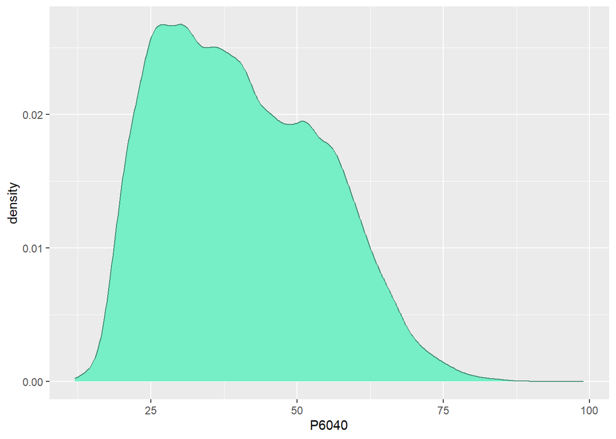

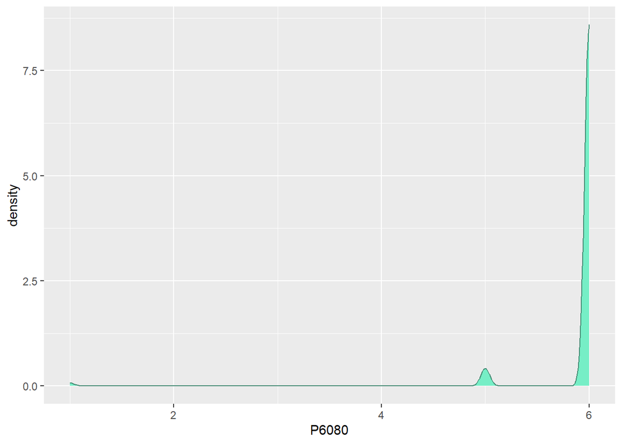

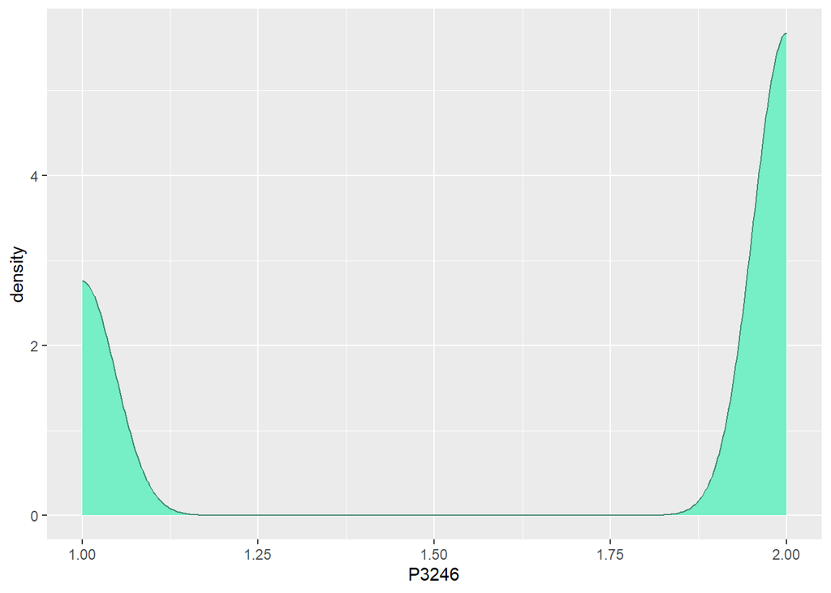

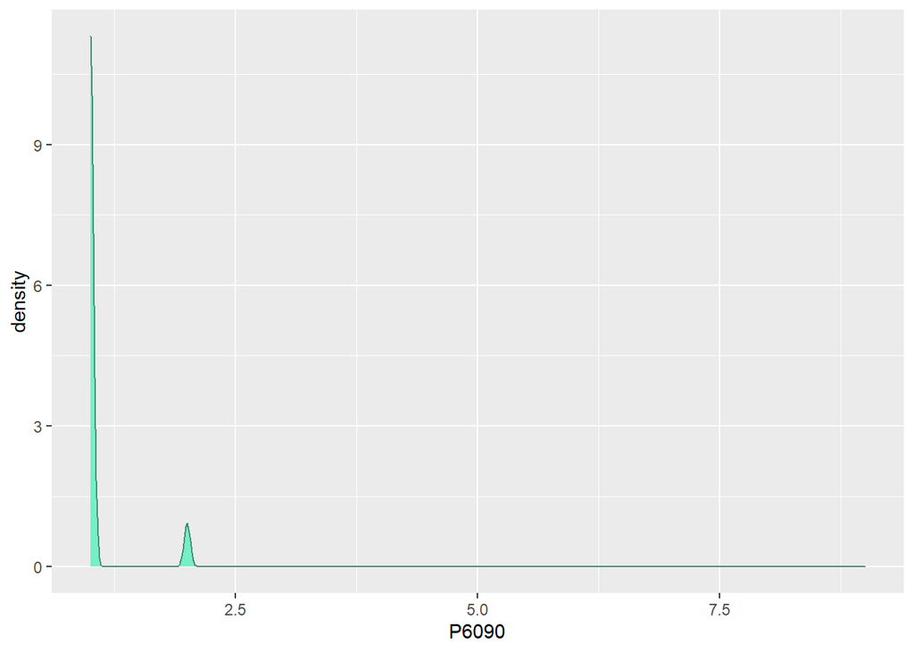

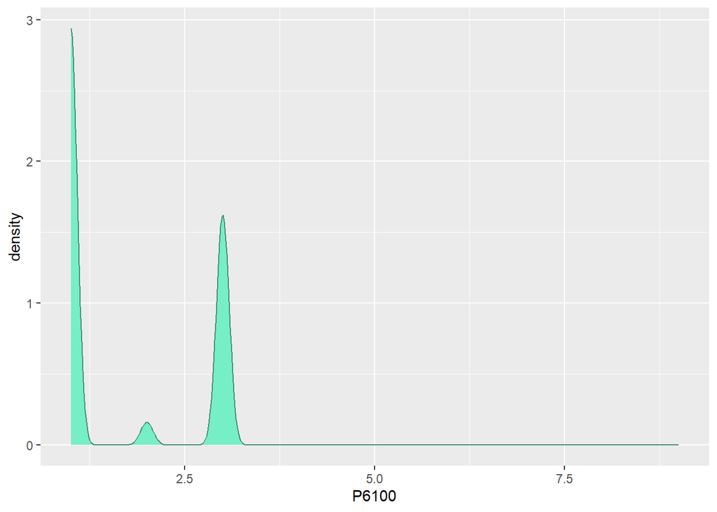

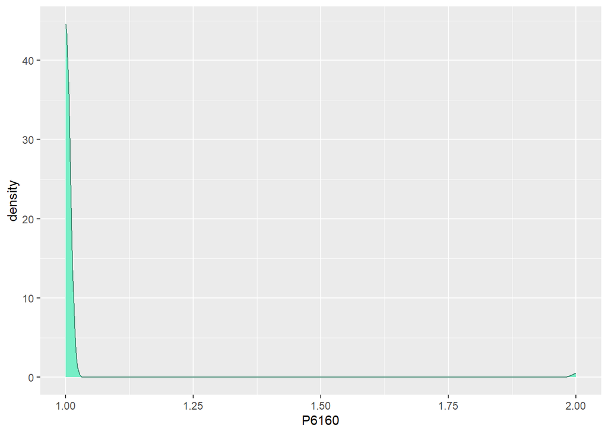

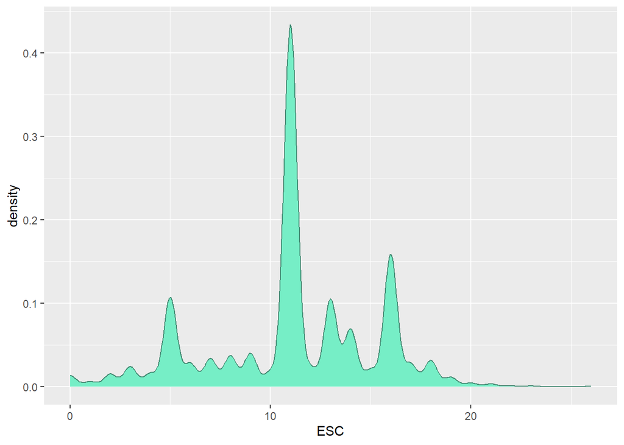

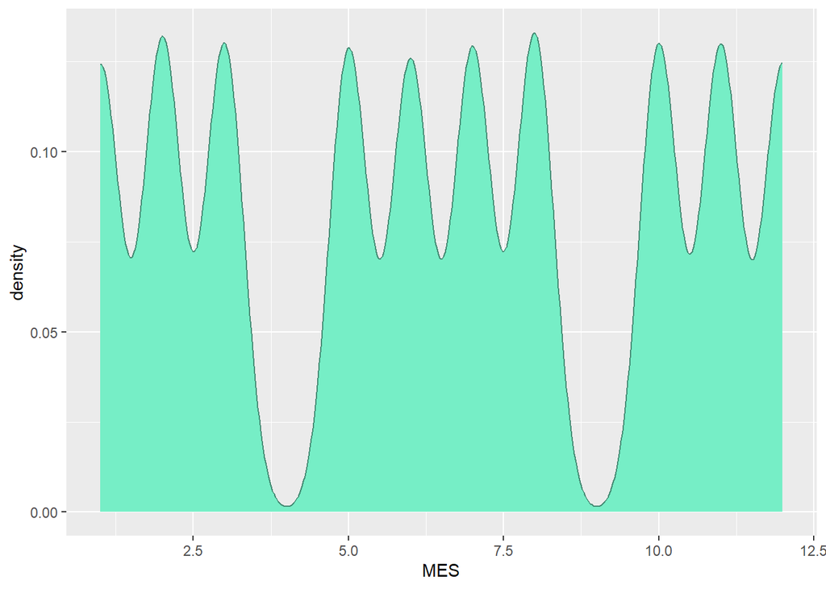

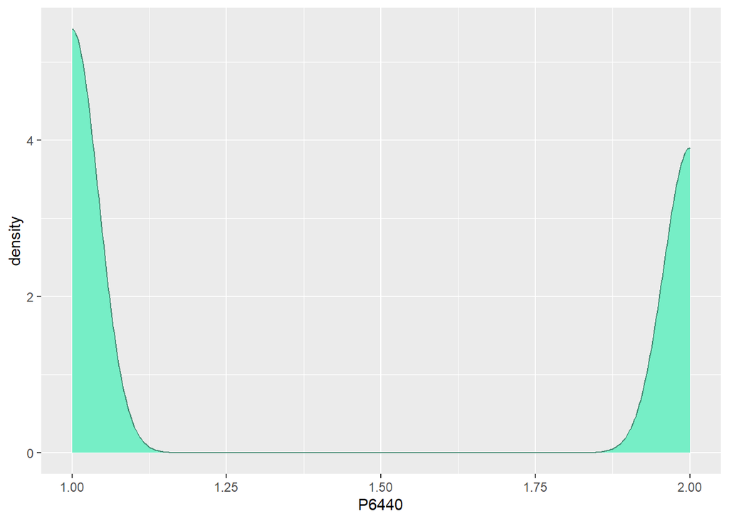

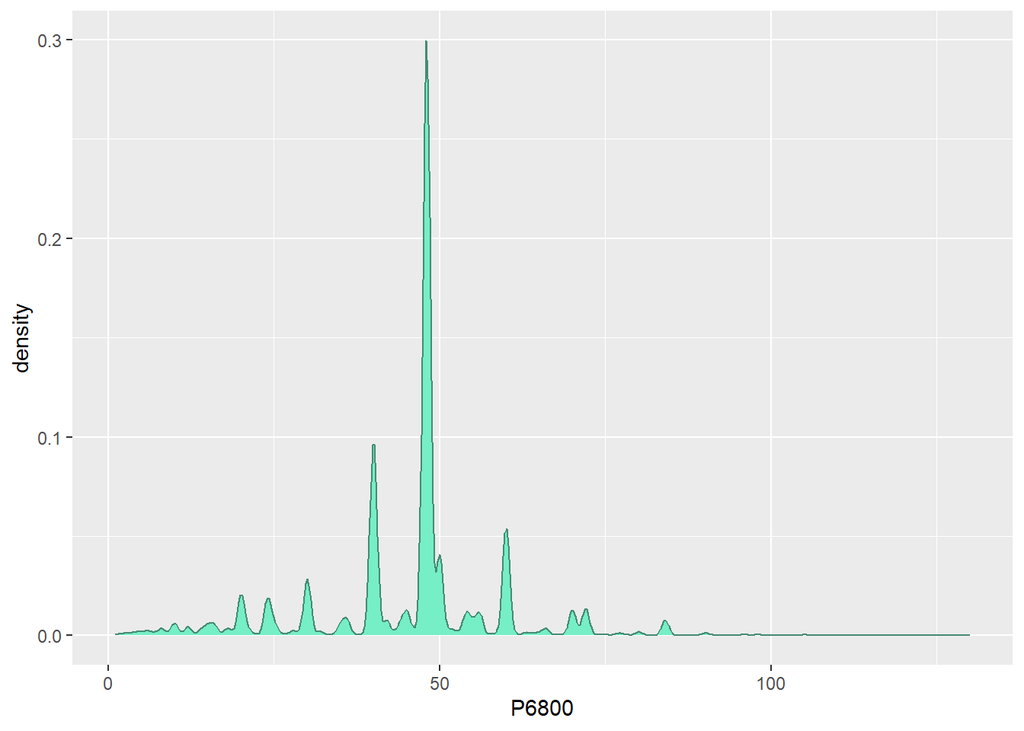

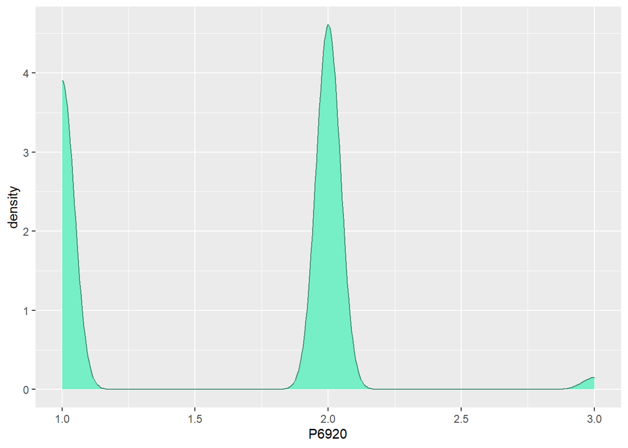

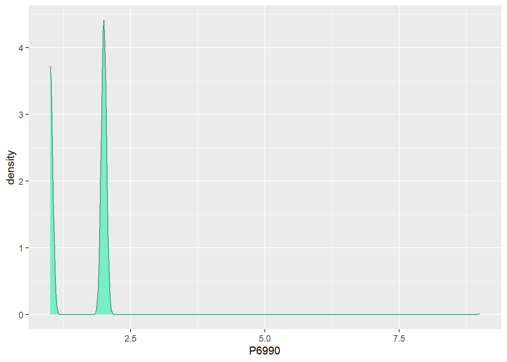

[2 more figures not shown]

```r
for (i in colnames(data_GEIH)) {
  if (is.numeric(data_GEIH[[i]])) {
    densidad <- ggplot(data_GEIH, aes(x = .data[[i]])) + geom_density(col = "#458B74", fill = "#76EEC6")
      labs(x = "X", y = "Frecuencia", title = paste("Histograma de", i))
    print(densidad)
  }
}
```

Según las gráficas de densidad en cada una de las variables, visualmente se puede suponer que la distribución de los datos para cada una de las variables no tienen una distribución normal.

### Matriz de correlación

```r
data <- data_GEIH %>% select_if(is.numeric)
data$P6090 <- NULL
head(data)
```

```
##   P6040 P6080 P3246 P6100 P6160 ESC MES P6440 P6800 P6920 P6990 P7180 INGLABO
## 1    53     6    NA     1     1  11   1     1    48     1     1     2  877803
## 2    20     6     1    NA     1  10   1     2    40     2     2     2  800000
## 3    43     6     1     3     1   7   1     2    60     2     2     2  150000
## 4    27     6    NA     1     1  11   1     1    48     1     1     2 1100000
## 5    31     6     2     3     1  16   1     2    48     2     2     2  600000
## 6    33     6    NA     1     1  11   1     1    48     1     2     2  877803
```

```r
data.cor <- cor(data, use = "complete.obs", method = "spearman")
round(data.cor, digits = 2)
```

```
##         P6040 P6080 P3246 P6100 P6160   ESC   MES P6440 P6800 P6920 P6990 P7180
## P6040    1.00  0.00 -0.05  0.11  0.11 -0.27  0.00  0.26 -0.13  0.26  0.23 -0.08
## P6080    0.00  1.00  0.10 -0.03 -0.01  0.03  0.01  0.00  0.03 -0.01 -0.01  0.00
## P3246   -0.05  0.10  1.00 -0.32 -0.08  0.30 -0.02 -0.18  0.06 -0.26 -0.28 -0.08
## P6100    0.11 -0.03 -0.32  1.00  0.12 -0.40  0.01  0.46 -0.11  0.64  0.68  0.03
## P6160    0.11 -0.01 -0.08  0.12  1.00 -0.19  0.00  0.08 -0.04  0.09  0.10  0.02
## ESC     -0.27  0.03  0.30 -0.40 -0.19  1.00  0.00 -0.30 -0.04 -0.40 -0.43 -0.19
## MES      0.00  0.01 -0.02  0.01  0.00  0.00  1.00 -0.01  0.01  0.01  0.01  0.00
## P6440    0.26  0.00 -0.18  0.46  0.08 -0.30 -0.01  1.00 -0.12  0.63  0.68  0.12
## P6800   -0.13  0.03  0.06 -0.11 -0.04 -0.04  0.01 -0.12  1.00 -0.15 -0.15  0.07
## P6920    0.26 -0.01 -0.26  0.64  0.09 -0.40  0.01  0.63 -0.15  1.00  0.85  0.11
## P6990    0.23 -0.01 -0.28  0.68  0.10 -0.43  0.01  0.68 -0.15  0.85  1.00  0.15
## P7180   -0.08  0.00 -0.08  0.03  0.02 -0.19  0.00  0.12  0.07  0.11  0.15  1.00
## INGLABO -0.15  0.04  0.37 -0.48 -0.12  0.56  0.04 -0.43  0.24 -0.55 -0.58 -0.20
##         INGLABO
## P6040     -0.15
## P6080      0.04
## P3246      0.37
## P6100     -0.48
## P6160     -0.12
## ESC        0.56
## MES        0.04
## P6440     -0.43
## P6800      0.24
## P6920     -0.55
## P6990     -0.58
## P7180     -0.20
## INGLABO    1.00
```

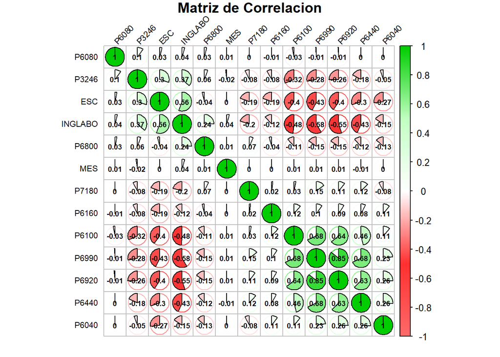

```r
color <- colorRampPalette(c( "#FF6A6A", "#FF3030", "#FFFFFF", "#C1FFC1", "#00CD00"))

corrplot(data.cor, method = "pie", tl.col = "black", tl.srt = 45, col = color(200),main = "Matriz de Correlacion", order = "AOE", tl.cex = 0.7, mar = c(1, 0, 1, 0), addCoef.col = "black", number.cex = 0.6)
```

### Variables con correlación mayor a 0.5

```r
nombres_variables <- colnames(data.cor)

coeficientes <- data.cor[which(data.cor > 0.5 | data.cor < -0.5, arr.ind = TRUE)]

coeficientes <- coeficientes[coeficientes!=1]

# Ordenar los coeficientes por valor absoluto en orden descendente
coeficientes_ordenados <- sort(coeficientes, decreasing = TRUE)

# Mostrar los coeficientes y sus nombres de variables en forma de lista
for (i in seq_along(coeficientes_ordenados)) {
  coef <- coeficientes_ordenados[i]
  variable <- nombres_variables[which(data.cor == coef, arr.ind = TRUE)[, "row"]]
  print(paste(variable, coef))
}
```

```
## [1] "P6990 0.854830259115477" "P6920 0.854830259115477"
## [1] "P6990 0.854830259115477" "P6920 0.854830259115477"
## [1] "P6990 0.681254685303957" "P6100 0.681254685303957"
## [1] "P6990 0.681254685303957" "P6100 0.681254685303957"
## [1] "P6990 0.679324865020939" "P6440 0.679324865020939"
## [1] "P6990 0.679324865020939" "P6440 0.679324865020939"
## [1] "P6920 0.640069467106808" "P6100 0.640069467106808"
## [1] "P6920 0.640069467106808" "P6100 0.640069467106808"
## [1] "P6920 0.625629152251715" "P6440 0.625629152251715"
## [1] "P6920 0.625629152251715" "P6440 0.625629152251715"
## [1] "INGLABO 0.559275459390966" "ESC 0.559275459390966"
## [1] "INGLABO 0.559275459390966" "ESC 0.559275459390966"
## [1] "INGLABO -0.54763577449964" "P6920 -0.54763577449964"
## [1] "INGLABO -0.54763577449964" "P6920 -0.54763577449964"
## [1] "INGLABO -0.584683957135661" "P6990 -0.584683957135661"
## [1] "INGLABO -0.584683957135661" "P6990 -0.584683957135661"
```

Según la matriz y el gráfico de correlaciones se puede evidenciar que las variables con mayor correlación son las siguientes:

P6990 (Afiliación a una ARP) y P6920 (Cotizando a pensión), correlación positiva = 0.85.

P6990 (Afiliación a una ARP) y P6100 (Regímenes de seguridad social afiliado), correlación positiva = 0.68.

P6990 (Afiliación a una ARP) y P6440 (Tipo de contrato), correlación = 0.68.

P6920 (Cotizando a pensión) y P6100 (Regímenes de seguridad social afiliado), correlación positiva = 0.64.

P6920 (Cotizando a pensión) y P6440 (Tipo de contrato), correlación positiva = 0.63.

INGLABO (Ingresos laborales) y ESC (Años de escolaridad), correlación positiva = 0.56.

INGLABO (Ingresos laborales) y P6920 (Cotizando a pensión), correlación negativa = -0.55.

INGLABO (Ingresos laborales) y P6990 (Afiliación a una ARP), correlación negativa = -0.58.

### Análisis de regresión variables: P6990 (Afiliación a una ARP) y P6920 (Cotizando a pensión)

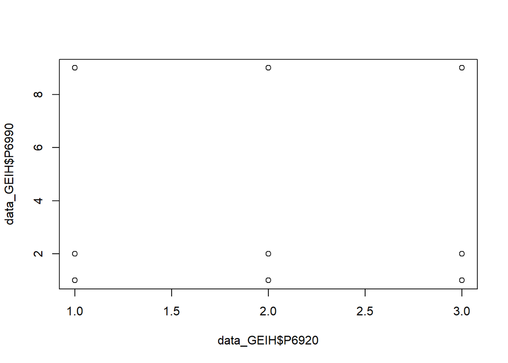

```r
plot(data_GEIH$P6920, data_GEIH$P6990)
```

```r
#Modelo de Regresión

model <- lm(P6920~P6990, data = data_GEIH)
model
```

```
##
## Call:
## lm(formula = P6920 ~ P6990, data = data_GEIH)
##
## Coefficients:
## (Intercept)        P6990
##      0.4135       0.7445
```

```r
diag_model <- augment(model)
head(diag_model)
```

```
## # A tibble: 6 × 9
##   .rownames P6920 P6990 .fitted  .resid      .hat .sigma     .cooksd .std.resid
##   <chr>     <int> <int>   <dbl>   <dbl>     <dbl>  <dbl>       <dbl>      <dbl>
## 1 1             1     1    1.16 -0.158  0.0000165  0.335 0.00000183      -0.471
## 2 2             2     2    1.90  0.0976 0.0000138  0.335 0.000000585      0.291
## 3 3             2     2    1.90  0.0976 0.0000138  0.335 0.000000585      0.291
## 4 4             1     1    1.16 -0.158  0.0000165  0.335 0.00000183      -0.471
## 5 5             2     2    1.90  0.0976 0.0000138  0.335 0.000000585      0.291
## 6 6             1     2    1.90 -0.902  0.0000138  0.335 0.0000500       -2.69
```

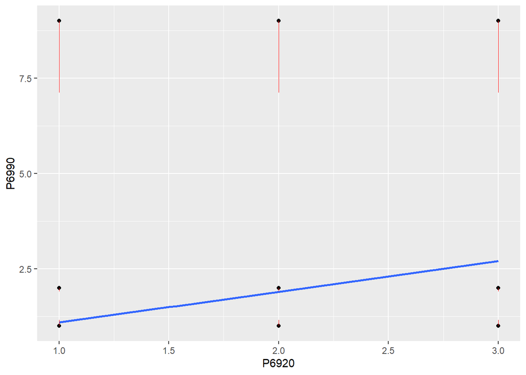

```r
#Grafico de regresion

ggplot(diag_model, aes(P6920, P6990)) + geom_point() + stat_smooth(method = lm, se = FALSE) +
  geom_segment(aes(xend = P6920, yend = .fitted ), color = "red", size = 0.3)
```

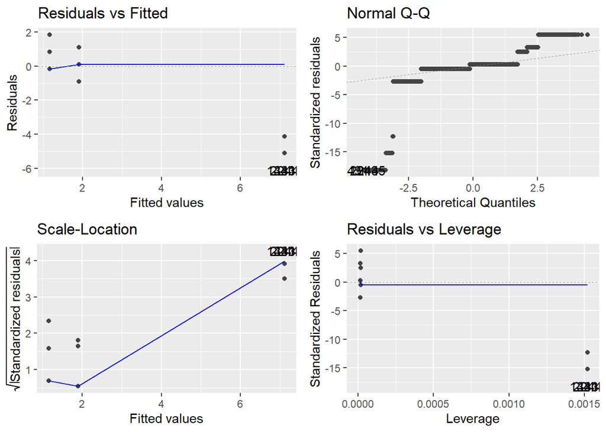

```r
autoplot(model)
```

Según el grafico de residuos estandarizados vs los cuantiles teoricos (Normal Q-Q) podemos observar que hay muchos datos que estan lejos de la linea de regresión, por tal razón, lo más probable es que los residuos se alejan de una hipotesis de normalidad. A continuación confirmamos con la prueba de shpairo wilks la hipotesis de si los datos tienen una distribución normal

```r
res = model$residuals
muestra_res <- sample(res, 5000)
x.test <- shapiro.test(muestra_res)
x.test
```

```
##
##  Shapiro-Wilk normality test
##
## data:  muestra_res
## W = 0.53446, p-value < 2.2e-16
```

P-valor por debajo del 5% es decir que se rechaza la suposición de que los datos tienen distribución normal.

### Análisis de regresión variables: INGLABO (Ingresos laborales) y ESC (Años de escolaridad).

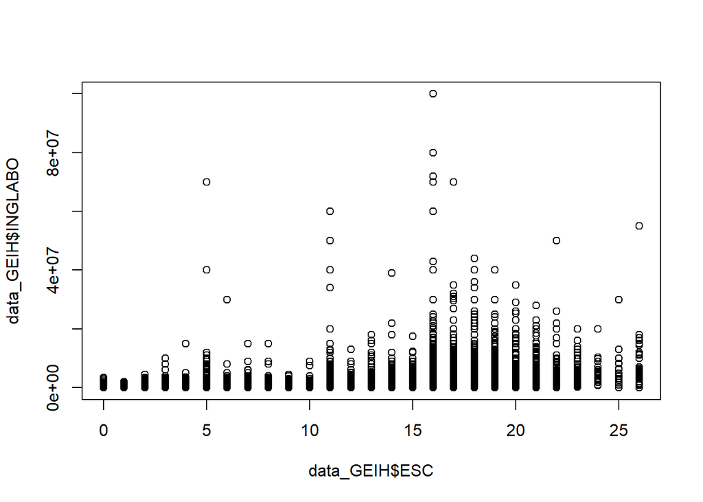

```r
plot(data_GEIH$ESC, data_GEIH$INGLABO)
```

```r
model_2 <- lm(ESC~INGLABO, data = data_GEIH)
model_2
```

```
##
## Call:
## lm(formula = ESC ~ INGLABO, data = data_GEIH)
##
## Coefficients:
## (Intercept)      INGLABO
##   9.884e+00    9.543e-07
```

```r
diag_model_2 <- augment(model_2)
head(diag_model_2)
```

```
## # A tibble: 6 × 9
##   .rownames   ESC INGLABO .fitted  .resid       .hat .sigma      .cooksd .std.…¹
##   <chr>     <int>   <int>   <dbl>   <dbl>      <dbl>  <dbl>        <dbl>   <dbl>
## 1 1            11  877803    10.7  0.279  0.00000935   3.82      2.50e-8  0.0731
## 2 2            10  800000    10.6 -0.647  0.00000955   3.82      1.37e-7 -0.170
## 3 3             7  150000    10.0 -3.03   0.0000127    3.82      4.01e-6 -0.793
## 4 4            11 1100000    10.9  0.0668 0.00000902   3.82      1.38e-9  0.0175
## 5 5            16  600000    10.5  5.54   0.0000102    3.82      1.08e-5  1.45
## 6 6            11  877803    10.7  0.279  0.00000935   3.82      2.50e-8  0.0731
## # … with abbreviated variable name ¹.std.resid
```

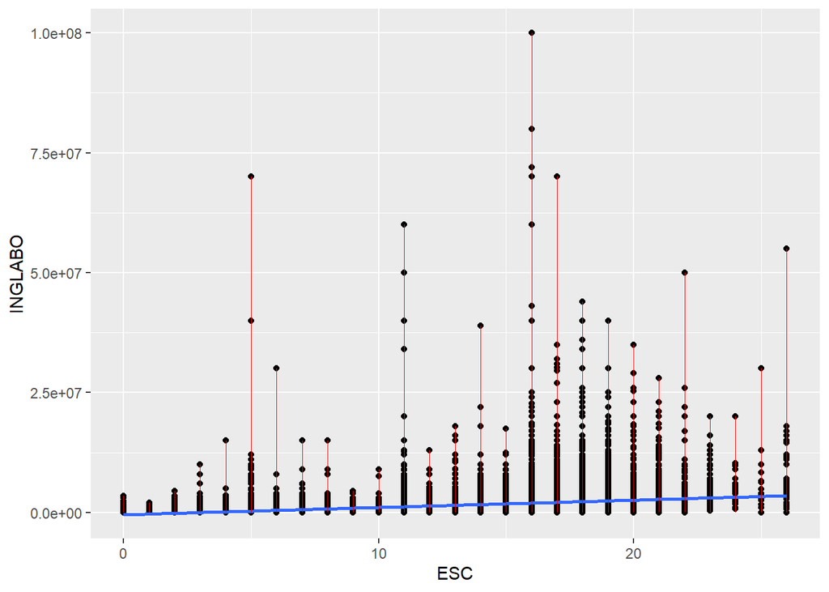

```r
ggplot(diag_model_2, aes(ESC, INGLABO)) + geom_point() + stat_smooth(method = lm, se = FALSE) + geom_segment(aes(xend = ESC, yend = .fitted), color = "red", size = 0.3)
```

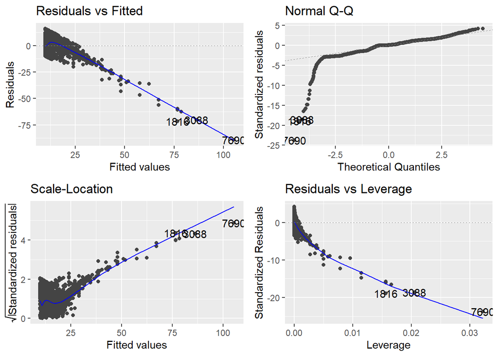

```r
autoplot(model_2)
```

En el gráfico de cuantiles de residuos, podemos observar que la mayoría de los puntos siguen una distribución normal porque siguen la linea, sin embargo se evidencian datos que que violan dicho supuesto de normalidad.

```r
res_2 = model_2$residuals
muestra_res_2 <- sample(res_2, 5000)
test_2 <- shapiro.test(muestra_res_2)
test_2
```

```
##
##  Shapiro-Wilk normality test
##
## data:  muestra_res_2
## W = 0.94916, p-value < 2.2e-16
```

Valor-p inferior al 5%, razón por la cual rechaza la suposición de que los valores tienen una distribución normal y asumimos que no presentan normalidad en sus distribución.